# Demonstration code: Parvovirus time-series analysis in R

V Brookes, M Ward, R Iglesias

24 October 2019

# Time-series analysis of the parvovirus dataset

First, load the required packages (libraries).

To manipulate and plot the data:

```r
library(ggplot2)
library(plyr)
library(dplyr)
library(lubridate)
```

To conduct time-series analyses and read the data from github:

```r
library(tseries)
library(vars)
library(forecast)
library(RCurl)
```

Now load the parvo dataset, and inspect it using the `summary`, `str`, `head` and `tail` functions:

```r
dataSource_CPV = getURL("https://raw.githubusercontent.com/vbrookes/Timeseries_analysis/master/Parvo_TS_clean.csv")
ParvoD <- read.csv(text = dataSource_CPV, header = T)
summary(ParvoD)
```

```
##     Case.ID           Case.Date         Day              Week
##  Min.   :    1   26/11/2012:  10   Min.   :   1.0   Min.   :  1.0
##  1st Qu.: 2882   17/01/2011:   9   1st Qu.: 418.0   1st Qu.: 59.0
##  Median : 6990   5/11/2010 :   9   Median : 920.0   Median :131.0
##  Mean   : 8220   12/05/2010:   8   Mean   : 949.7   Mean   :135.3
##  3rd Qu.:13372   19/05/2010:   8   3rd Qu.:1459.0   3rd Qu.:208.0
##  Max.   :20245   25/11/2013:   8   Max.   :2218.0   Max.   :316.0
##                  (Other)   :2935
##      Cases          Events
##  Min.   : 1.0   Min.   :1
##  1st Qu.: 1.0   1st Qu.:1
##  Median : 1.0   Median :1
##  Mean   : 1.2   Mean   :1
##  3rd Qu.: 1.0   3rd Qu.:1
##  Max.   :13.0   Max.   :1
##
```

```r
str(ParvoD)
```

```
## 'data.frame':    2987 obs. of  6 variables:
##  $ Case.ID  : int  1 693 695 697 46 632 3 4 701 5 ...
##  $ Case.Date: Factor w/ 1423 levels "1/02/2010","1/02/2011",..: 1261 1261 1410 174 396 448 818 865 865 40 ...
##  $ Day      : int  1 1 4 7 12 13 20 21 21 27 ...
##  $ Week     : int  1 1 1 1 2 2 3 3 3 4 ...
##  $ Cases    : int  1 1 1 1 1 1 1 1 1 1 ...
##  $ Events   : int  1 1 1 1 1 1 1 1 1 1 ...
```

```r
head(ParvoD)
```

```
##   Case.ID  Case.Date Day Week Cases Events
## 1       1  6/10/2009   1    1     1      1
## 2     693  6/10/2009   1    1     1      1
## 3     695  9/10/2009   4    1     1      1
## 4     697 12/10/2009   7    1     1      1
## 5      46 17/10/2009  12    2     1      1
## 6     632 18/10/2009  13    2     1      1
```

```r
tail(ParvoD)
```

```
##      Case.ID  Case.Date  Day Week Cases Events
## 2982   20244 26/10/2015 2212  315     1      1
## 2983   20150 26/10/2015 2212  315     1      1
## 2984   20243 27/10/2015 2213  316     1      1
## 2985   20183 28/10/2015 2214  316     1      1
## 2986   20234 30/10/2015 2216  316     1      1
## 2987   20245  1/11/2015 2218  316     2      1
```

Check for duplicated or missing data:

```r
## Duplication
which(duplicated(ParvoD))  # anyDuplicated() does the same thing
```

```
## integer(0)
```

```r
AllCompleteData = unique(ParvoD) # Can check that the dataset is the same length

#missing values in entire data set
ParvoD$complete<-complete.cases(ParvoD) # shows you if there are missing values in the row. If row is complete=TRUE
length(ParvoD$complete)
```

```
## [1] 2987
```

```r
missingData <- ParvoD[which(ParvoD$complete == "FALSE"),]
missingData
```

```
## [1] Case.ID   Case.Date Day       Week      Cases     Events    complete
## <0 rows> (or 0-length row.names)
```

Re-check your data, for example: How many observations are there? What are the data types of each column? Are they suitable for analysis?

Note that the column ‘Case.Date’ is a factor.

Convert it to date format, and find the minumum and maximum dates in the dataset. Also, add columns for week and month for aggregation purposes later in analysis:

```r
length(ParvoD$complete) # total events
```

```
## [1] 2987
```

```r
str(ParvoD)
```

```
## 'data.frame':    2987 obs. of  7 variables:
##  $ Case.ID  : int  1 693 695 697 46 632 3 4 701 5 ...
##  $ Case.Date: Factor w/ 1423 levels "1/02/2010","1/02/2011",..: 1261 1261 1410 174 396 448 818 865 865 40 ...
##  $ Day      : int  1 1 4 7 12 13 20 21 21 27 ...
##  $ Week     : int  1 1 1 1 2 2 3 3 3 4 ...
##  $ Cases    : int  1 1 1 1 1 1 1 1 1 1 ...
##  $ Events   : int  1 1 1 1 1 1 1 1 1 1 ...
##  $ complete : logi  TRUE TRUE TRUE TRUE TRUE TRUE ...
```

```r
sum(ParvoD$Cases) # total cases
```

```
## [1] 3584
```

```r
sum(ParvoD$Events) # total events
```

```
## [1] 2987
```

```r
## Save Case.Date to Date in a new column, with as.Date format
ParvoD$Date = as.Date(ParvoD$Case.Date, "%d/%m/%Y")

## Remove rows with no date (this should also have been detected in the previous chunk of code).
ParvoD <- subset(ParvoD,!(is.na(ParvoD["Date"]) ))

## Add columns that are by week or month
ParvoD$byWeek = cut(ParvoD$Date, breaks="1 week")
ParvoD$byMonth = cut(ParvoD$Date, breaks="1 month")

## find the minimum and maximum dates of observations
min(ParvoD$Date, na.rm = T)
```

```
## [1] "2009-10-06"
```

```r
max(ParvoD$Date, na.rm = T)
```

```
## [1] "2015-11-01"
```

Summarise dataset by week and month, using `ddply` from the `plyr` package:

```r
#### Aggregate data by week
ParvoW = ddply(ParvoD, c("byWeek"), summarise,
                     Cases = sum(Cases),
                     Events = sum(Events))
ParvoW$byWeek <-  as.Date(ParvoW$byWeek, format = "%Y-%m-%d")
str(ParvoW)
```

```
## 'data.frame':    315 obs. of  3 variables:
##  $ byWeek: Date, format: "2009-10-05" "2009-10-12" ...
##  $ Cases : int  3 3 1 3 3 1 4 1 2 8 ...
##  $ Events: int  3 3 1 3 3 1 4 1 2 5 ...
```

```r
summary(ParvoW)
```

```
##      byWeek               Cases           Events
##  Min.   :2009-10-05   Min.   : 1.00   Min.   : 1.000
##  1st Qu.:2011-04-14   1st Qu.: 5.00   1st Qu.: 5.000
##  Median :2012-10-15   Median : 9.00   Median : 8.000
##  Mean   :2012-10-15   Mean   :11.38   Mean   : 9.483
##  3rd Qu.:2014-04-17   3rd Qu.:16.00   3rd Qu.:13.000
##  Max.   :2015-10-26   Max.   :45.00   Max.   :30.000
```

```r
ParvoM = ddply(ParvoD, c("byMonth"), summarise,
                     Cases = sum(Cases),
                     Events = sum(Events))
ParvoM$byMonth <-  as.Date(ParvoM$byMonth, format = "%Y-%m-%d")
str(ParvoM)
```

```
## 'data.frame':    74 obs. of  3 variables:
##  $ byMonth: Date, format: "2009-10-01" "2009-11-01" ...
##  $ Cases  : int  9 9 21 49 66 66 104 114 62 51 ...
##  $ Events : int  9 9 18 45 62 60 93 97 55 44 ...
```

```r
summary(ParvoM)
```

```
##     byMonth               Cases            Events
##  Min.   :2009-10-01   Min.   :  2.00   Min.   : 1.00
##  1st Qu.:2011-04-08   1st Qu.: 29.25   1st Qu.:22.00
##  Median :2012-10-16   Median : 43.00   Median :34.00
##  Mean   :2012-10-15   Mean   : 48.43   Mean   :40.36
##  3rd Qu.:2014-04-23   3rd Qu.: 66.00   3rd Qu.:54.50
##  Max.   :2015-11-01   Max.   :115.00   Max.   :97.00
```

Now create a dummy time-series of weeks based on these time periods and merge with the time-series. This identifies weeks (or months) with no cases. Note that some time-series have many zero values at the time points.

```r
# Create time sequence with 1 week intervals
data.length <- length(ParvoW$byWeek)
min.date = min(ParvoW$byWeek)
max.date = max(ParvoW$byWeek)

# Check length
length(ParvoW$Events)
```

```
## [1] 315
```

```r
all.dates <- seq(min.date, max.date, by="week")
all.dates.frame <- data.frame(list(byWeek=all.dates))  # Make it into a data frame so that we can merge it

# Merge data with weekly Parvo data
ParvoW <- merge(all.dates.frame, ParvoW, all = T)
# Change NAs to 0
ParvoW$Cases[is.na(ParvoW$Cases)] <- 0
ParvoW$Events[is.na(ParvoW$Events)] <- 0

# summary
summary(ParvoW)
```

```
##      byWeek               Cases           Events
##  Min.   :2009-10-05   Min.   : 0.00   Min.   : 0.000
##  1st Qu.:2011-04-11   1st Qu.: 5.00   1st Qu.: 4.000
##  Median :2012-10-15   Median : 9.00   Median : 8.000
##  Mean   :2012-10-15   Mean   :11.31   Mean   : 9.423
##  3rd Qu.:2014-04-21   3rd Qu.:16.00   3rd Qu.:13.000
##  Max.   :2015-10-26   Max.   :45.00   Max.   :30.000
```

```r
# check structure
str(ParvoW)
```

```
## 'data.frame':    317 obs. of  3 variables:
##  $ byWeek: Date, format: "2009-10-05" "2009-10-12" ...
##  $ Cases : num  3 3 1 3 0 3 1 4 1 2 ...
##  $ Events: num  3 3 1 3 0 3 1 4 1 2 ...
```

```r
# Check length
length(ParvoW$Events) # Note that in this dataset, there must be 2 weeks with 0 cases (because this is two weeks longer).
```

```
## [1] 317
```

We can also create a monthly times-series.

```r
# Create time sequence with 1 month intervals
data.lengthM <- length(ParvoM$byMonth)
min.dateM = min(ParvoM$byMonth)
max.dateM = max(ParvoM$byMonth)

# Check length
length(ParvoM$Cases)
```

```
## [1] 74
```

```r
all.dates <- seq(min.dateM, max.dateM, by="month")
all.dates.frame <- data.frame(list(byMonth=all.dates))  # Make it into a data frame so that we can merge it

# Merge data with monthly Parvo data
ParvoM <- merge(all.dates.frame, ParvoM, all = T)
# Change NAs to 0
ParvoM$Cases[which(is.na(ParvoM$Cases))] <- 0
ParvoM$Events[which(is.na(ParvoM$Events))] <- 0

# summary
summary(ParvoM)
```

```
##     byMonth               Cases            Events
##  Min.   :2009-10-01   Min.   :  2.00   Min.   : 1.00
##  1st Qu.:2011-04-08   1st Qu.: 29.25   1st Qu.:22.00
##  Median :2012-10-16   Median : 43.00   Median :34.00
##  Mean   :2012-10-15   Mean   : 48.43   Mean   :40.36
##  3rd Qu.:2014-04-23   3rd Qu.: 66.00   3rd Qu.:54.50
##  Max.   :2015-11-01   Max.   :115.00   Max.   :97.00
```

```r
# check structure
str(ParvoM)
```

```
## 'data.frame':    74 obs. of  3 variables:
##  $ byMonth: Date, format: "2009-10-01" "2009-11-01" ...
##  $ Cases  : num  9 9 21 49 66 66 104 114 62 51 ...
##  $ Events : num  9 9 18 45 62 60 93 97 55 44 ...
```

```r
write.csv(ParvoM, 'D:/Users/vbrookes/Dropbox (Sydney Uni)/Parvo_timeseries/Parvo_Month.csv')
# Check length
length(ParvoM$Events)
```

```
## [1] 74
```

## Exploratory analysis

### Plot the weekly time-series

Here, we use `ggplot`. The following code is used to make the plots attractive and is a useful ‘publication-ready’ theme:

```r
themeVB = theme(axis.text.x = element_text(colour = "black", angle = 90, hjust=1,vjust=0.5, size = 11),
                axis.line = element_line(colour = "black"),
                axis.text.y = element_text(colour = "black"),
                axis.ticks = element_line(colour = "black"),
                axis.title.y = element_text(vjust=1.5),
                panel.grid.major = element_line(colour = "grey93"),
                panel.grid.minor = element_line(colour = "white"),
                panel.background = element_blank(),
                legend.background = element_rect(colour = NA),
                legend.key = element_rect(fill = 'transparent'))
```

The blue line is the smoothed number of cases with a shaded 95% confidence interval. You can change the smoothing method (here, we have used ‘auto’).

There seems to be an overall decreasing trend in the number of weekly reported cases. Seasonality is also possible but difficult to determine using this plot.

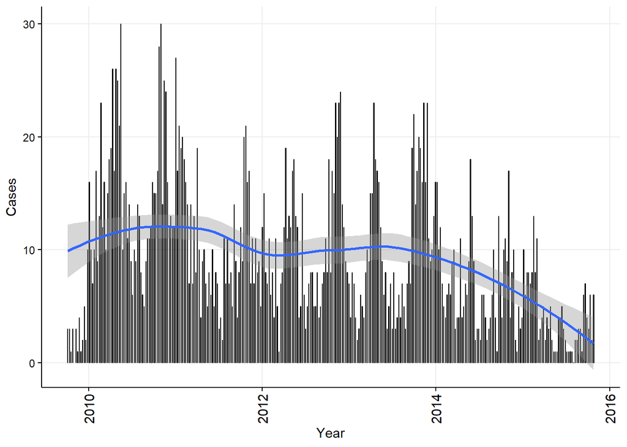

```r
ggplot(ParvoW, aes(x = byWeek, y = Events, group = 1)) +
  geom_bar(stat="identity", width = 0.5, colour = "black") +
  stat_smooth(aes(y = Events), method='auto', level=0.95) +
  themeVB +
  scale_x_date() +
  xlab("Year") +
  ylab("Cases")
```

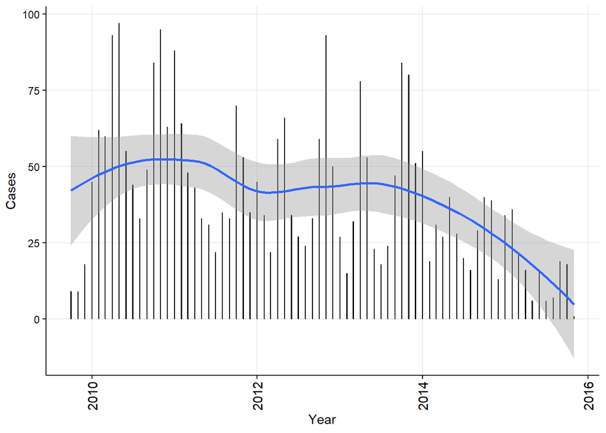

```r
ggplot(ParvoM, aes(x = byMonth, y = Events, group = 1)) +
  geom_bar(stat="identity", width = 0.5, colour = "black") +
  stat_smooth(aes(y = Events), method='auto', level=0.95) +
  themeVB +
  scale_x_date() +
  xlab("Year") +
  ylab("Cases")
```

### Convert the data to an R recognised time-series

Here, we use the `ts` function from the stats package.

`frequency = 52` is specified because there are 52 weeks (sort of) in a year.

```r
Parvo_ts_data <- ts(ParvoW$Events, start = c(2009, 40), frequency =52)

Parvo_ts_dataM <- ts(ParvoM$Events, start = c(2009, 10), frequency =12)
```

There are a decreasing number of events over time.

We can quantify this trend using linear regression with predictor variables for trend (by week or month per year) and seasonality (week or month)

The weekly change in the number of cases is -1.22 events/week/year (95% CI -1.57 - -0.87), confirming that the long-term trend is decreasing reported cases.

```r
# Weekly ts dataset
fit_Parvo_data = ts_all_model <- lm(Parvo_ts_data ~ time(Parvo_ts_data) + factor(cycle(Parvo_ts_data)))
summary(fit_Parvo_data)
```

```
##
## Call:
## lm(formula = Parvo_ts_data ~ time(Parvo_ts_data) + factor(cycle(Parvo_ts_data)))
##
## Residuals:
##      Min       1Q   Median       3Q      Max
## -17.2400  -2.8324  -0.1095   2.7762  14.9429
##
## Coefficients:
##                                 Estimate Std. Error t value Pr(>|t|)
## (Intercept)                    2474.6667   360.1895   6.870 4.59e-11 ***
## time(Parvo_ts_data)              -1.2229     0.1790  -6.833 5.74e-11 ***
## factor(cycle(Parvo_ts_data))2    -1.6432     3.2057  -0.513  0.60868
## factor(cycle(Parvo_ts_data))3    -3.6196     3.2057  -1.129  0.25988
## factor(cycle(Parvo_ts_data))4    -3.0961     3.2057  -0.966  0.33503
## factor(cycle(Parvo_ts_data))5    -2.4059     3.2058  -0.751  0.45362
## factor(cycle(Parvo_ts_data))6    -5.7158     3.2058  -1.783  0.07574 .
## factor(cycle(Parvo_ts_data))7    -4.8589     3.2058  -1.516  0.13080
## factor(cycle(Parvo_ts_data))8    -2.5021     3.2058  -0.780  0.43581
## factor(cycle(Parvo_ts_data))9    -5.1452     3.2058  -1.605  0.10970
## factor(cycle(Parvo_ts_data))10   -4.1217     3.2059  -1.286  0.19969
## factor(cycle(Parvo_ts_data))11   -7.2648     3.2059  -2.266  0.02426 *
## factor(cycle(Parvo_ts_data))12   -3.7413     3.2059  -1.167  0.24427
## factor(cycle(Parvo_ts_data))13   -5.0511     3.2060  -1.576  0.11633
## factor(cycle(Parvo_ts_data))14   -1.0276     3.2060  -0.321  0.74882
## factor(cycle(Parvo_ts_data))15   -0.6708     3.2061  -0.209  0.83444
## factor(cycle(Parvo_ts_data))16   -1.6473     3.2061  -0.514  0.60784
## factor(cycle(Parvo_ts_data))17   -1.1237     3.2062  -0.350  0.72625
## factor(cycle(Parvo_ts_data))18   -0.9336     3.2063  -0.291  0.77115
## factor(cycle(Parvo_ts_data))19   -1.5767     3.2063  -0.492  0.62331
## factor(cycle(Parvo_ts_data))20   -1.2199     3.2064  -0.380  0.70392
## factor(cycle(Parvo_ts_data))21   -4.8630     3.2065  -1.517  0.13056
## factor(cycle(Parvo_ts_data))22   -3.5062     3.2065  -1.093  0.27520
## factor(cycle(Parvo_ts_data))23   -3.9826     3.2066  -1.242  0.21534
## factor(cycle(Parvo_ts_data))24   -6.9591     3.2067  -2.170  0.03088 *
## factor(cycle(Parvo_ts_data))25   -4.9356     3.2068  -1.539  0.12497
## factor(cycle(Parvo_ts_data))26   -7.2454     3.2069  -2.259  0.02468 *
## factor(cycle(Parvo_ts_data))27   -9.7219     3.2070  -3.031  0.00268 **
## factor(cycle(Parvo_ts_data))28   -8.0317     3.2071  -2.504  0.01287 *
## factor(cycle(Parvo_ts_data))29   -8.3415     3.2072  -2.601  0.00982 **
```

[output cut: 14 more lines]

```
## factor(cycle(Parvo_ts_data))44    0.3045     3.0897   0.099  0.92156
## factor(cycle(Parvo_ts_data))45    1.1452     3.2058   0.357  0.72121
## factor(cycle(Parvo_ts_data))46   -0.4979     3.2058  -0.155  0.87668
## factor(cycle(Parvo_ts_data))47    0.5256     3.2058   0.164  0.86990
## factor(cycle(Parvo_ts_data))48   -0.2842     3.2058  -0.089  0.92941
## factor(cycle(Parvo_ts_data))49   -5.0941     3.2058  -1.589  0.11325
## factor(cycle(Parvo_ts_data))50   -5.7372     3.2057  -1.790  0.07465 .
## factor(cycle(Parvo_ts_data))51   -5.8804     3.2057  -1.834  0.06773 .
## factor(cycle(Parvo_ts_data))52   -5.1902     3.2057  -1.619  0.10663
## ---
## Signif. codes:  0 '***' 0.001 '**' 0.01 '*' 0.05 '.' 0.1 ' ' 1
##
## Residual standard error: 5.552 on 264 degrees of freedom
## Multiple R-squared:  0.3429, Adjusted R-squared:  0.2135
## F-statistic:  2.65 on 52 and 264 DF,  p-value: 2.098e-07
```

```r
confint(fit_Parvo_data)
```

```
##                                      2.5 %       97.5 %
## (Intercept)                    1765.456986 3183.8763478
## time(Parvo_ts_data)              -1.575252   -0.8704618
## factor(cycle(Parvo_ts_data))2    -7.955196    4.6688959
## factor(cycle(Parvo_ts_data))3    -9.931691    2.6924233
## factor(cycle(Parvo_ts_data))4    -9.408192    3.2159579
## factor(cycle(Parvo_ts_data))5    -8.718035    3.9061665
## factor(cycle(Parvo_ts_data))6   -12.027884    0.5963824
## factor(cycle(Parvo_ts_data))7   -11.171074    1.4532723
## factor(cycle(Parvo_ts_data))8    -8.814272    3.8101694
## factor(cycle(Parvo_ts_data))9   -11.457477    1.1670738
## factor(cycle(Parvo_ts_data))10  -10.434022    2.1906521
## factor(cycle(Parvo_ts_data))11  -13.577241   -0.9524290
## factor(cycle(Parvo_ts_data))12  -10.053801    2.5711639
## factor(cycle(Parvo_ts_data))13  -11.363702    1.2614307
## factor(cycle(Parvo_ts_data))14   -7.340276    5.2850381
## factor(cycle(Parvo_ts_data))15   -6.983525    5.6419862
## factor(cycle(Parvo_ts_data))16   -7.960114    4.6656081
## factor(cycle(Parvo_ts_data))17   -7.436710    5.1892374
## factor(cycle(Parvo_ts_data))18   -7.246647    5.3795406
## factor(cycle(Parvo_ts_data))19   -7.889924    4.7365177
## factor(cycle(Parvo_ts_data))20   -7.533209    5.0935021
## factor(cycle(Parvo_ts_data))21  -11.176501    1.4504937
## factor(cycle(Parvo_ts_data))22   -9.819800    2.8074927
## factor(cycle(Parvo_ts_data))23  -10.296440    2.3311655
## factor(cycle(Parvo_ts_data))24  -13.273087   -0.6451543
## factor(cycle(Parvo_ts_data))25  -11.249742    1.3785331
## factor(cycle(Parvo_ts_data))26  -13.559737   -0.9311056
## factor(cycle(Parvo_ts_data))27  -16.036406   -3.4074036
## factor(cycle(Parvo_ts_data))28  -14.346416   -1.7170277
## factor(cycle(Parvo_ts_data))29  -14.656432   -2.0266446
## factor(cycle(Parvo_ts_data))30  -11.966456    0.6637458
## factor(cycle(Parvo_ts_data))31  -12.776488   -0.1458565
## factor(cycle(Parvo_ts_data))32  -14.253193   -1.6221182
## factor(cycle(Parvo_ts_data))33  -14.229906   -1.5983727
## factor(cycle(Parvo_ts_data))34  -13.873292   -1.2412865
## factor(cycle(Parvo_ts_data))35  -14.183353   -1.5508598
## factor(cycle(Parvo_ts_data))36  -10.826754    1.8062409
## factor(cycle(Parvo_ts_data))37  -12.303495    0.3300155
## factor(cycle(Parvo_ts_data))38  -12.780244   -0.1462027
## factor(cycle(Parvo_ts_data))39   -6.757000    5.8775864
## factor(cycle(Parvo_ts_data))40   -9.301169    2.8649790
## factor(cycle(Parvo_ts_data))41   -9.992041    2.1743117
## factor(cycle(Parvo_ts_data))42   -8.111491    4.0550805
## factor(cycle(Parvo_ts_data))43   -4.802377    7.3644283
## factor(cycle(Parvo_ts_data))44   -5.778985    6.3880693
## factor(cycle(Parvo_ts_data))45   -5.167074    7.4574767
## factor(cycle(Parvo_ts_data))46   -6.810169    5.8142719
## factor(cycle(Parvo_ts_data))47   -5.786606    6.8377411
## factor(cycle(Parvo_ts_data))48   -6.596382    6.0278843
## factor(cycle(Parvo_ts_data))49  -11.406167    1.2180347
## factor(cycle(Parvo_ts_data))50  -12.049291    0.5748590
## factor(cycle(Parvo_ts_data))51  -12.192423    0.4316907
## factor(cycle(Parvo_ts_data))52  -11.502229    1.1218629
```

```r
# Monthly ts dataset
fit_Parvo_dataM = ts_all_model <- lm(Parvo_ts_dataM ~ time(Parvo_ts_dataM) + factor(cycle(Parvo_ts_dataM)))
summary(fit_Parvo_dataM)
```

```
##
## Call:
## lm(formula = Parvo_ts_dataM ~ time(Parvo_ts_dataM) + factor(cycle(Parvo_ts_dataM)))
##
## Residuals:
##     Min      1Q  Median      3Q     Max
## -61.136  -8.408  -0.440   9.684  40.143
##
## Coefficients:
##                                  Estimate Std. Error t value Pr(>|t|)
## (Intercept)                     11640.477   2758.508   4.220 8.25e-05 ***
## time(Parvo_ts_dataM)               -5.760      1.371  -4.202 8.77e-05 ***
## factor(cycle(Parvo_ts_dataM))2    -10.187     12.028  -0.847   0.4004
## factor(cycle(Parvo_ts_dataM))3    -12.207     12.030  -1.015   0.3143
## factor(cycle(Parvo_ts_dataM))4      5.107     12.033   0.424   0.6728
## factor(cycle(Parvo_ts_dataM))5      2.087     12.036   0.173   0.8629
## factor(cycle(Parvo_ts_dataM))6    -15.433     12.041  -1.282   0.2048
## factor(cycle(Parvo_ts_dataM))7    -23.287     12.047  -1.933   0.0579 .
## factor(cycle(Parvo_ts_dataM))8    -22.473     12.054  -1.864   0.0671 .
## factor(cycle(Parvo_ts_dataM))9    -10.160     12.062  -0.842   0.4029
## factor(cycle(Parvo_ts_dataM))10     4.440     11.595   0.383   0.7031
## factor(cycle(Parvo_ts_dataM))11     5.777     11.599   0.498   0.6202
## factor(cycle(Parvo_ts_dataM))12   -11.147     12.028  -0.927   0.3577
## ---
## Signif. codes:  0 '***' 0.001 '**' 0.01 '*' 0.05 '.' 0.1 ' ' 1
##
## Residual standard error: 20.83 on 61 degrees of freedom
## Multiple R-squared:  0.3766, Adjusted R-squared:  0.254
## F-statistic: 3.071 on 12 and 61 DF,  p-value: 0.00193
```

```r
confint(fit_Parvo_dataM)
```

```
##                                       2.5 %        97.5 %
## (Intercept)                     6124.499204 17156.4553418
## time(Parvo_ts_dataM)              -8.500586    -3.0188946
## factor(cycle(Parvo_ts_dataM))2   -34.238596    13.8652191
## factor(cycle(Parvo_ts_dataM))3   -36.261871    11.8484507
## factor(cycle(Parvo_ts_dataM))4   -18.953980    29.1671835
## factor(cycle(Parvo_ts_dataM))5   -21.981589    26.1547494
## factor(cycle(Parvo_ts_dataM))6   -39.511363     8.6444796
## factor(cycle(Parvo_ts_dataM))7   -47.376631     0.8030383
## factor(cycle(Parvo_ts_dataM))8   -46.577392     1.6304221
## factor(cycle(Parvo_ts_dataM))9   -34.280307    13.9599606
## factor(cycle(Parvo_ts_dataM))10  -18.746145    27.6260150
## factor(cycle(Parvo_ts_dataM))11  -17.416897    28.9710099
## factor(cycle(Parvo_ts_dataM))12  -35.198552    12.9052624
```

### Decompose the time-series

The observed data is composed of trend, cycle, seasonal and random variation.

The function `decompose` is from the base package `stats`, and uses moving averages to smooth the time-series. We also demonstrate the function ‘stl’ from the stats package which uses loess smoothing.

The data are illustrated as follows:

Observed - the actual data.

Trend - the overall upward or downward movement of the data points. It is not necessarily linear.

Seasonal - any monthly/yearly pattern of the data points.

Random (remainder) - unexplainable part of the data.

```r
# Weekly ts dataset
Decompose_ts <- decompose(Parvo_ts_data)
summary(Decompose_ts)
```

```
##          Length Class  Mode
## x        317    ts     numeric
## seasonal 317    ts     numeric
## trend    317    ts     numeric
## random   317    ts     numeric
## figure    52    -none- numeric
## type       1    -none- character
```

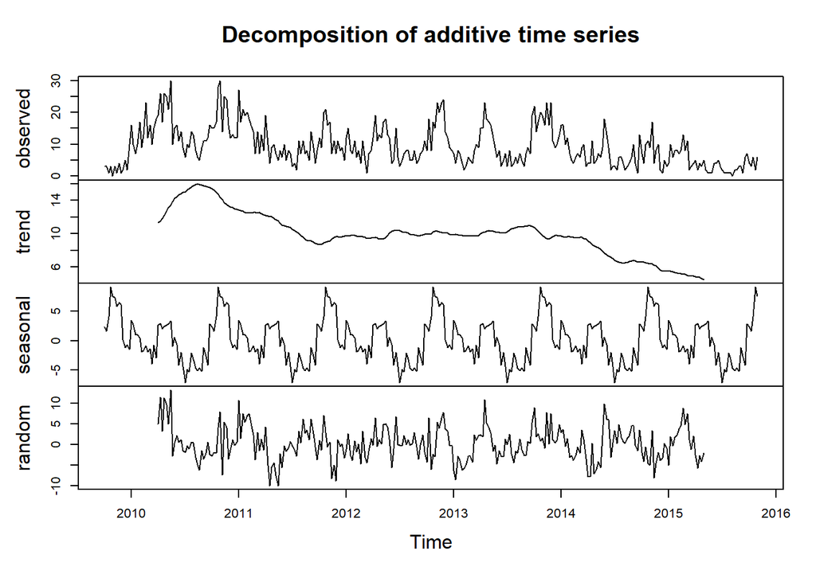

```r
plot(Decompose_ts)
```

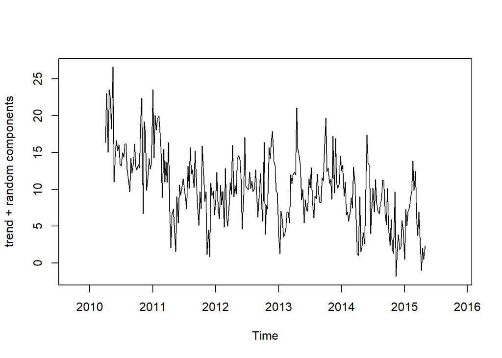

```r
plot(Decompose_ts$trend + Decompose_ts$random, ylab = "trend + random components")  # can also plot combinations
```

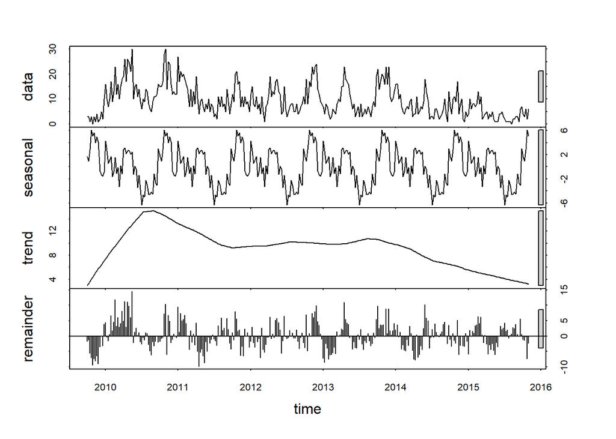

```r
Decompose_ts_loess <- stl(Parvo_ts_data, s.window="periodic")
plot(Decompose_ts_loess)
```

```r
# Monthly ts dataset
Decompose_tsM <- decompose(Parvo_ts_dataM)
summary(Decompose_tsM)
```

```
##          Length Class  Mode
## x        74     ts     numeric
## seasonal 74     ts     numeric
## trend    74     ts     numeric
## random   74     ts     numeric
## figure   12     -none- numeric
## type      1     -none- character
```

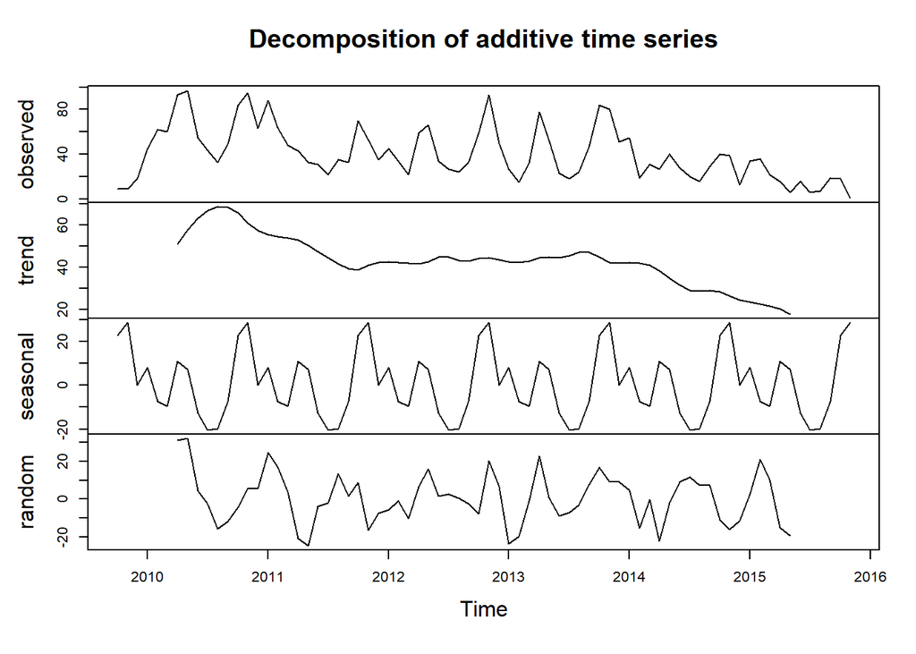

```r
plot(Decompose_tsM)
```

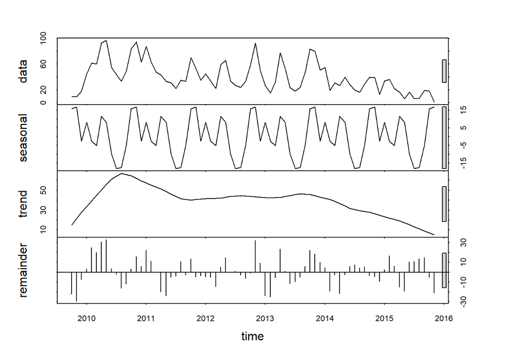

```r
Decompose_ts_loessM <- stl(Parvo_ts_dataM, s.window="periodic")
plot(Decompose_ts_loessM)
```

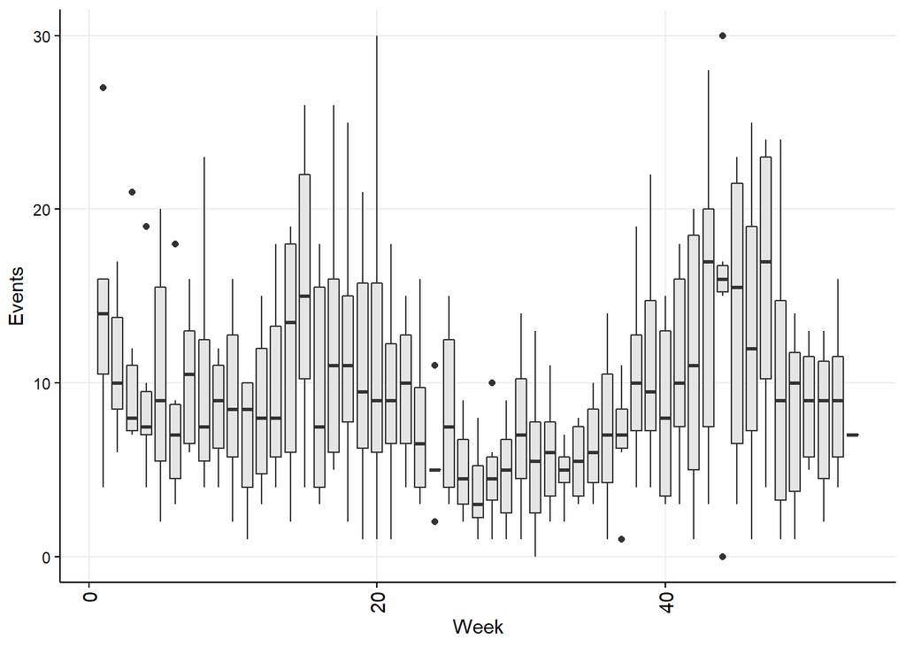

```r
## There looks like seasonality. Add a week and month column to ParvoW to investigate further
ParvoW$Year = year(ParvoW$byWeek)
ParvoW$Week = week(ParvoW$byWeek)
ParvoW$Month = month(ParvoW$byWeek)

ggplot(ParvoW, aes(y=Events, x = Week)) + geom_boxplot(aes(group=Week), fill = 'grey90') + themeVB
```

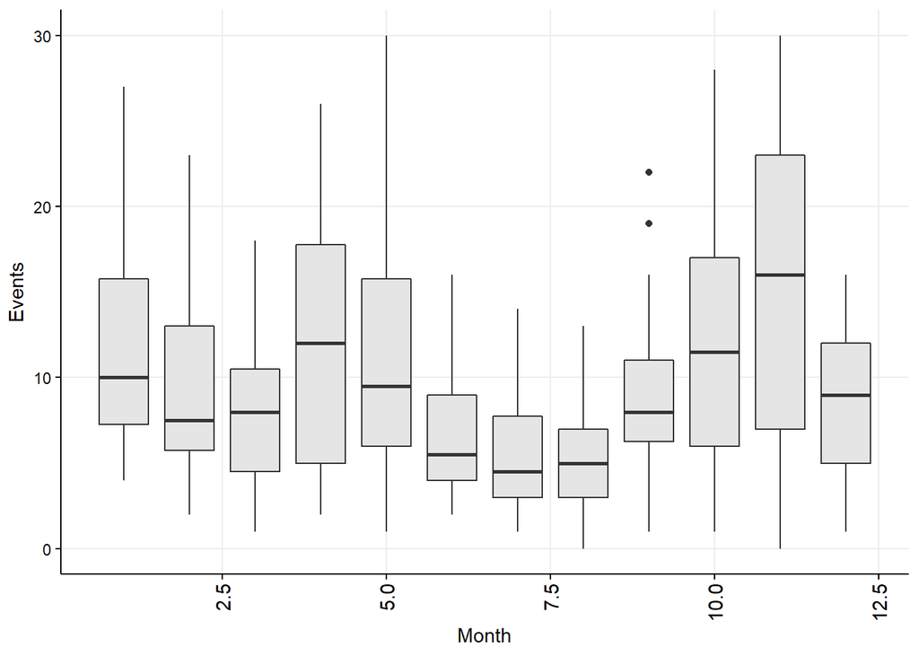

```r
ggplot(ParvoW, aes(y=Events, x = Month)) + geom_boxplot(aes(group=Month), fill = 'grey90') + themeVB
```

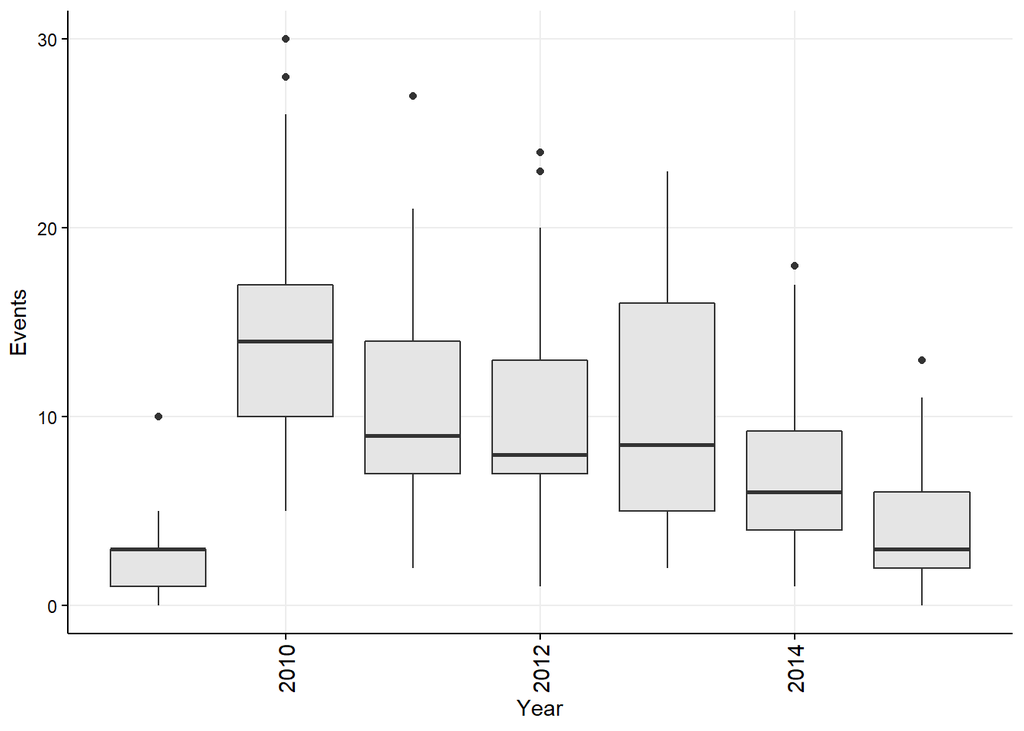

```r
ggplot(ParvoW, aes(y=Events, x = Year)) + geom_boxplot(aes(group=Year), fill = 'grey90') + themeVB
```

Given the apparent seasonality in both the weekly and monthly time-series, it is interesting to visually compare the two seasonal plots from the ‘decomposed’ data.

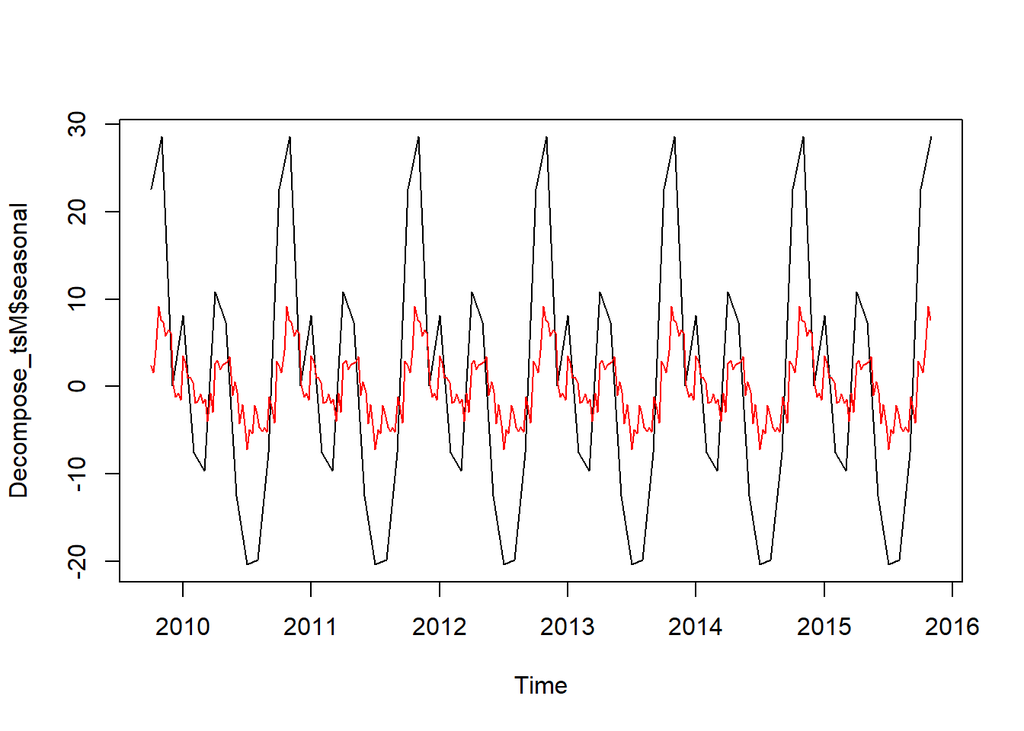

```r
### Compare the seasonality plots

plot(Decompose_tsM$seasonal)
lines(Decompose_ts$seasonal, col = 'red')
```

# Time-series analysis using autoregressive models

In this example, we fit an ARIMA model. ARIMA is an abbreviation for ‘AutoRegressive Integrated Moving Average’.

Auto Regressive (AR) terms refer to the number of lagged values in the model. In the non-seasonal part of the model, the order of lagged values is termed ‘p’, and in the seasonal part of the model the order of lagged values is termed ‘P’.

Moving Average (MA) terms refer to the number of lagged errors in the model. In the non-seasonal part of the model, the order of lagged errors is termed ‘q’, and in the seasonal part of the model the order of lagged errors is termed ‘Q’.

Integration (I) terms refer to the number of difference used to make the time series stationary. In the non-seasonal part of the model, the order of differences is termed ‘d’, and in the seasonal part of the model the order of differences is termed ‘D’.

Overall, the model includes the following variables:

ARIMA: (p, d, q) (P, D, Q)m

where m refers to the number of observations in a seasonal cycle.

#### Assumptions of ARIMA models

Data should be stationary - this means that the properties of the series do not depend on the time when it is captured, i.e. trend and seasonality are removed to leave ‘white-noise’. Note that a series with cyclic behaviour can also be considered stationary because cyclic behaviours have unpredictable wavelengths. A stationary series will have constant variance (see below)

#### Steps to be followed for ARIMA modeling:

1. Exploratory analysis - to determine values for (p, d, q) (P, D, Q)m
2. Fit the model
3. Diagnostic measures to assess model fit

## 1. Exploratory analysis for ARIMA modelling

We start by assessing the need for differencing to determine values for d and D.

### Tests for stationarity (is there a need to ‘first difference’ the data?)

It is important that the data to which the ARIMA model is fitted are stationary. Observations in a non-stationary time-series demonstrate structure that is dependent on the time index. Inducing stationarity means removing trend, seasonality and possibly cyclicity (if it is predictable).

There are several methods to check for stationarity:

1. View plots of time-series for obvious trend, or examine the autocorrelation function (ACF) plots. There should be little autocorrelation in stationary data, so an ACF plot should decrease to zero rapidly, and stay at zero.
2. Summary statistics Check for significant differences in mean and variance between sections of data. We do not demonstrate this in the current study because these are starighforward statistical tests.
3. Statistical tests These tests determine whether the expectations of stationarity are met or violated.

In our example dataset, we initially re-examine the time series and examine an ACF plot of the weekly and monthly events. We observe decreasing trend and the ACF plot demonstrates that there is autocorrelation for 10 and 2 lags in the weekly and monthly series, respectively. These time-series are not stationary.

We then run `ndiffs` from the `forecast` package to assess how many first differences are needed to induce stationarity. `ndiffs` suggests 1 first difference for each time series. After differencing the data, the time-series plots appears level (no trend) and the ACF plots show limited autocorrelation (one lag) in the first few lags.

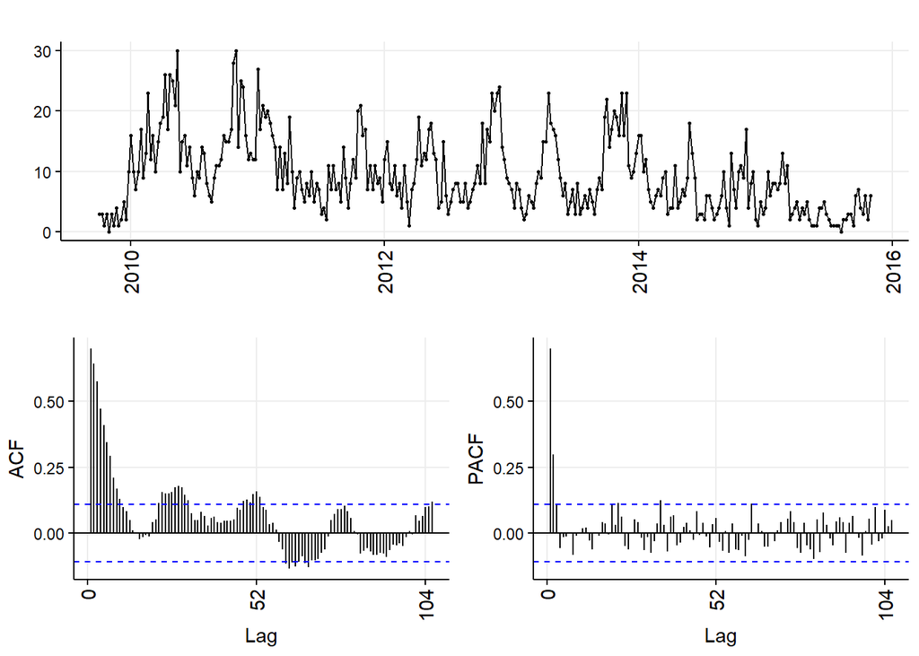

```r
## Tests for stationarity
# Weekly data
Parvo_ts_data %>% ggtsdisplay(theme = themeVB)
```

```r
ndiffs(Parvo_ts_data) # 1 difference estimated to induce stationarity
```

```
## [1] 1
```

```r
nsdiffs(Parvo_ts_data) # No differencing required to induce stationarity
```

```
## [1] 0
```

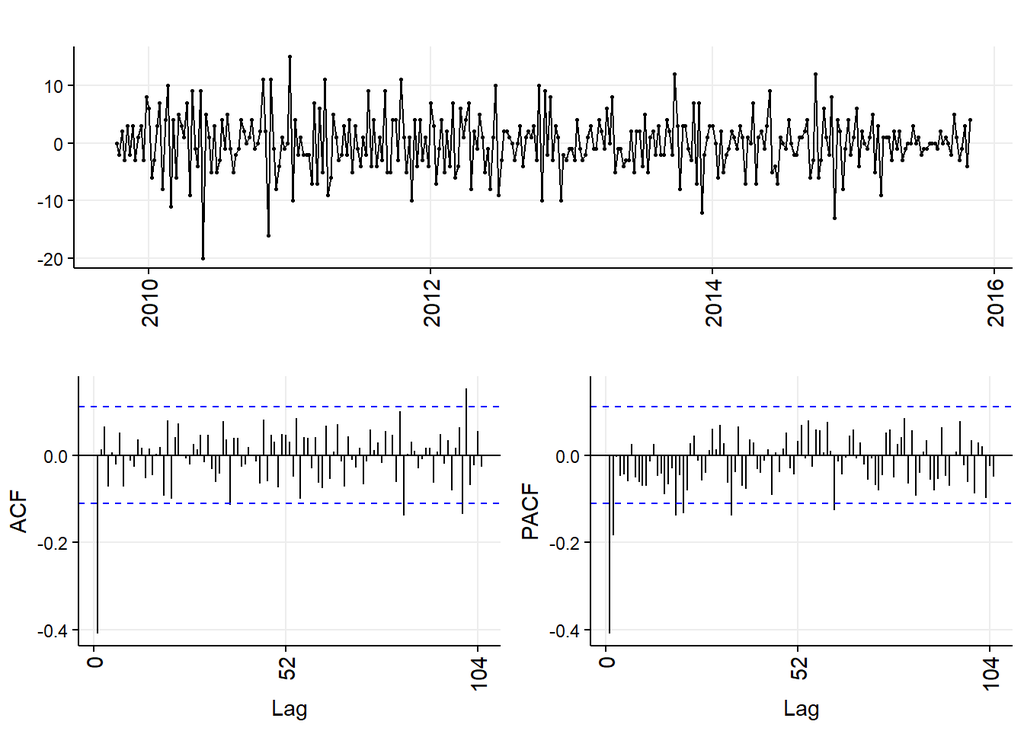

```r
Parvo_ts_data %>% diff() %>% ggtsdisplay(theme = themeVB) # Assess differenced ts and ACF and PACF plots.
```

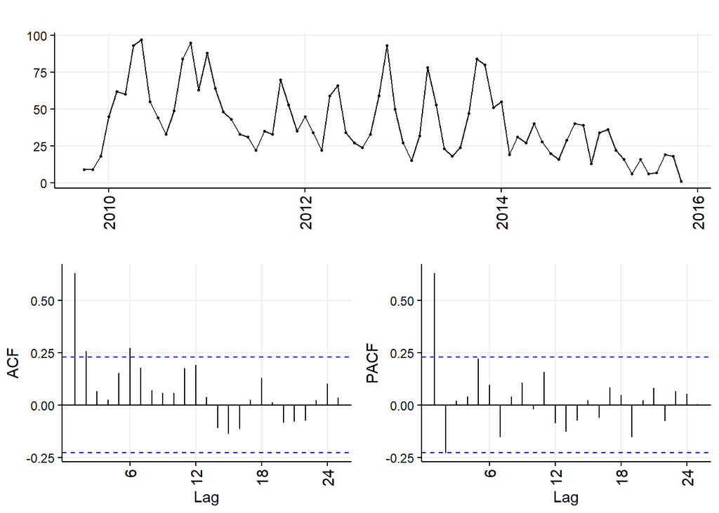

```r
# Monthly data
Parvo_ts_dataM %>% ggtsdisplay(theme = themeVB)
```

```r
ndiffs(Parvo_ts_dataM) # 1 difference estimated to induce stationarity
```

```
## [1] 1
```

```r
nsdiffs(Parvo_ts_dataM) # No differencing required to induce stationarity
```

```
## [1] 0
```

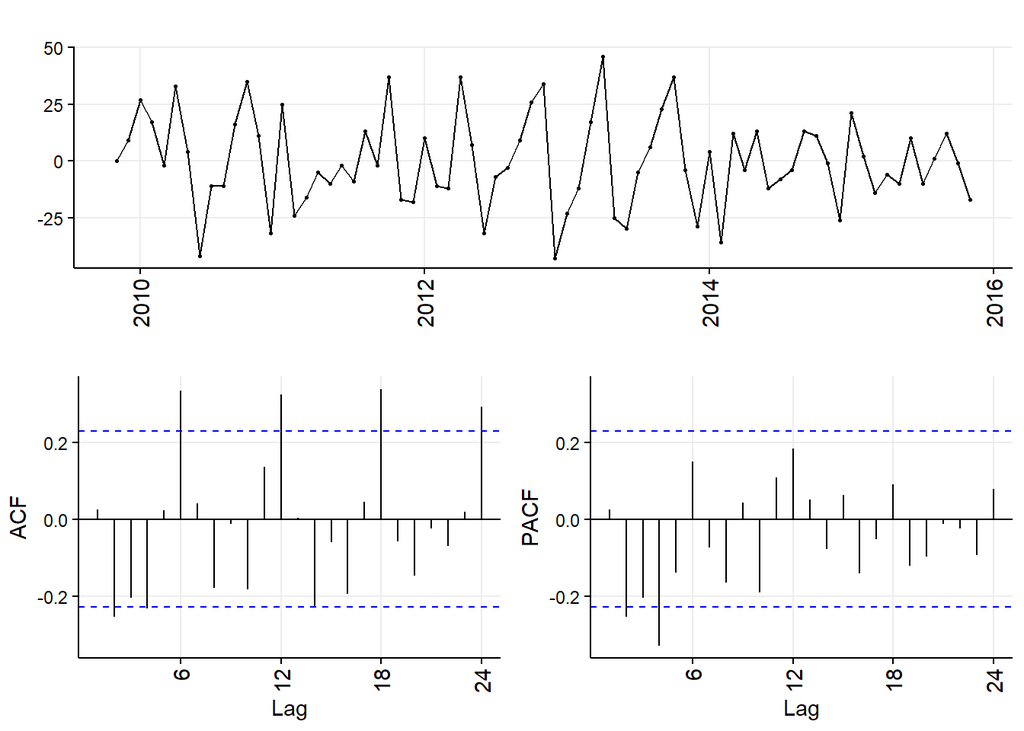

```r
Parvo_ts_dataM %>% diff() %>% ggtsdisplay(theme = themeVB) # Assess differenced ts and ACF and PACF plots.
```

We further check for stationarity in the time-series using statisical tests. [This website](https://rpubs.com/richkt/269797) is a useful resource.

Frequently used tests include:

1. Ljung-Box test for independence (Null hypothesis = time independance in a given period of lags. A low P value suggests that the data are not consistent with independance)
2. Augmented Dickey-Fuller (ADF) t-statistic test for unit root (note that a series with a trend line will have a unit root and result in a large P value, i.e. the null hypothesis is that there is a unit root present.)
3. Kwiatkowski-Phillips-Schmidt-Shin (KPSS) for level or trend stationarity (null hypothesis is that the time-series is stationary).

```r
## Weekly time-series tests for stationarity
# 1.
Box.test(Parvo_ts_data, lag = 52, type="Ljung-Box")
```

```
##
##  Box-Ljung test
##
## data:  Parvo_ts_data
## X-squared = 764.84, df = 52, p-value < 2.2e-16
```

```r
# 2.
adf.test(Parvo_ts_data, alternative = "stationary", k = 104)
```

```
##
##  Augmented Dickey-Fuller Test
##
## data:  Parvo_ts_data
## Dickey-Fuller = -1.3184, Lag order = 104, p-value = 0.8638
## alternative hypothesis: stationary
```

```r
# 3.
kpss.test(Parvo_ts_data, null = 'Trend') # The null hypothesis is a time trend with stationary error.
```

```
##
##  KPSS Test for Trend Stationarity
##
## data:  Parvo_ts_data
## KPSS Trend = 0.10897, Truncation lag parameter = 5, p-value = 0.1
```

```r
kpss.test(Parvo_ts_data, null = 'Level') # The null hypothesis is that the series is white noise.
```

```
##
##  KPSS Test for Level Stationarity
##
## data:  Parvo_ts_data
## KPSS Level = 1.1935, Truncation lag parameter = 5, p-value = 0.01
```

```r
## Monthly time-series tests for stationarity
# 1.
Box.test(Parvo_ts_dataM, lag = 12, type="Ljung-Box")
```

```
##
##  Box-Ljung test
##
## data:  Parvo_ts_dataM
## X-squared = 53.87, df = 12, p-value = 2.883e-07
```

```r
# 2.
adf.test(Parvo_ts_dataM, alternative = "stationary", k = 24)
```

```
##
##  Augmented Dickey-Fuller Test
##
## data:  Parvo_ts_dataM
## Dickey-Fuller = -0.84262, Lag order = 24, p-value = 0.9536
## alternative hypothesis: stationary
```

```r
# 3.
kpss.test(Parvo_ts_dataM, null = 'Trend') # The null hypothesis is a time trend with stationary error.
```

```
##
##  KPSS Test for Trend Stationarity
##
## data:  Parvo_ts_dataM
## KPSS Trend = 0.086265, Truncation lag parameter = 3, p-value = 0.1
```

```r
kpss.test(Parvo_ts_dataM, null = 'Level') # The null hypothesis is that the series is white noise.
```

```
##
##  KPSS Test for Level Stationarity
##
## data:  Parvo_ts_dataM
## KPSS Level = 0.71758, Truncation lag parameter = 3, p-value =
## 0.01195
```

We difference the time-series, then test for stationarity again.

```r
## Weekly time-series tests for stationarity
# 1.
Box.test(diff(Parvo_ts_data), lag=52, type="Ljung-Box")
```

```
##
##  Box-Ljung test
##
## data:  diff(Parvo_ts_data)
## X-squared = 96.191, df = 52, p-value = 0.0001887
```

```r
# 2.
adf.test(diff(Parvo_ts_data), alternative = "stationary", k = 104)
```

```
##
##  Augmented Dickey-Fuller Test
##
## data:  diff(Parvo_ts_data)
## Dickey-Fuller = -2.352, Lag order = 104, p-value = 0.428
## alternative hypothesis: stationary
```

```r
# 3.
kpss.test(diff(Parvo_ts_data), null = 'Trend') # The null hypothesis is a time trend with stationary error.
```

```
##
##  KPSS Test for Trend Stationarity
##
## data:  diff(Parvo_ts_data)
## KPSS Trend = 0.016653, Truncation lag parameter = 5, p-value = 0.1
```

```r
kpss.test(diff(Parvo_ts_data), null = 'Level') # The null hypothesis is that the series is white noise.
```

```
##
##  KPSS Test for Level Stationarity
##
## data:  diff(Parvo_ts_data)
## KPSS Level = 0.025954, Truncation lag parameter = 5, p-value = 0.1
```

```r
## Monthly time-series tests for stationarity
# 1.
Box.test(diff(Parvo_ts_dataM), lag=12, type="Ljung-Box")
```

```
##
##  Box-Ljung test
##
## data:  diff(Parvo_ts_dataM)
## X-squared = 38.561, df = 12, p-value = 0.0001243
```

```r
# 2.
adf.test(diff(Parvo_ts_dataM), alternative = "stationary", k = 24)
```

```
##
##  Augmented Dickey-Fuller Test
##
## data:  diff(Parvo_ts_dataM)
## Dickey-Fuller = -1.9387, Lag order = 24, p-value = 0.6003
## alternative hypothesis: stationary
```

```r
# 3.
kpss.test(diff(Parvo_ts_dataM), null = 'Trend') # The null hypothesis is a time trend with stationary error.
```

```
##
##  KPSS Test for Trend Stationarity
##
## data:  diff(Parvo_ts_dataM)
## KPSS Trend = 0.032465, Truncation lag parameter = 3, p-value = 0.1
```

```r
kpss.test(diff(Parvo_ts_dataM), null = 'Level') # The null hypothesis is that the series is white noise.
```

```
##
##  KPSS Test for Level Stationarity
##
## data:  diff(Parvo_ts_dataM)
## KPSS Level = 0.091647, Truncation lag parameter = 3, p-value = 0.1
```

### Interpreting ACF and PACF plots to determine p, d, P and D.

From our tests of stationarity, we know that ‘d’ in the non-seasonal part of the ARIMA model is likely to be 1, and ‘D’ in the seasonal part of the model is likely to be zero.

We now use the ACF and PACF plots of the differenced data to estimate the p and q values in the non-seasonal section of the ARIMA model.

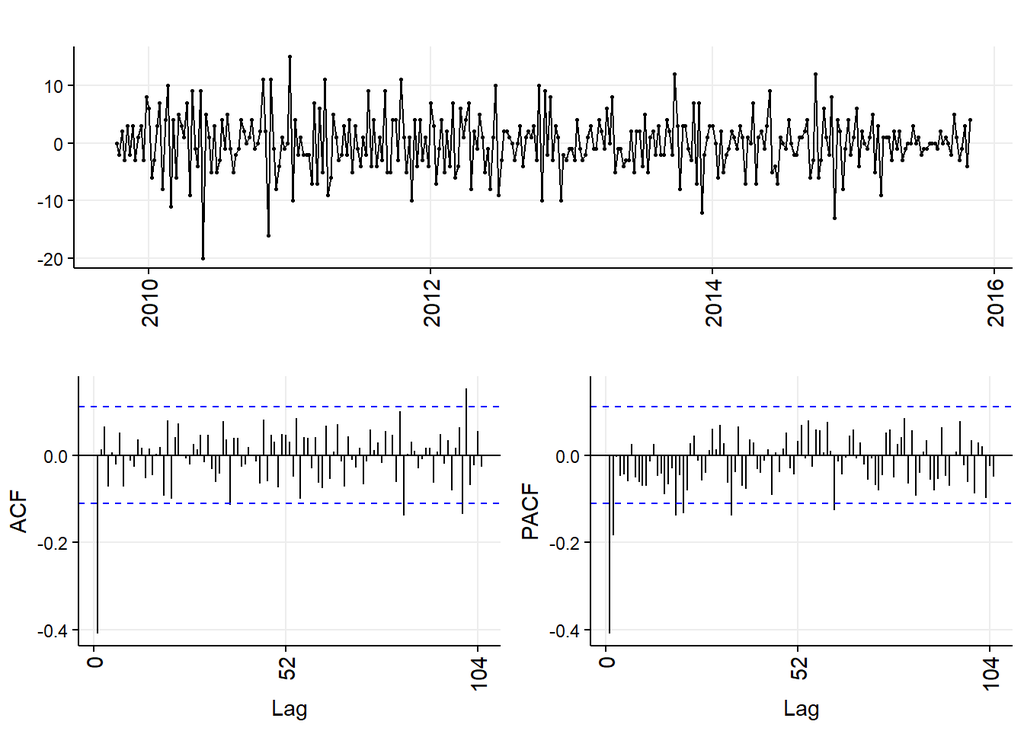

```r
## Examine ACF and PACF plots of differenced time-series again to estimate p, P, q and Q.
# Weekly data
Parvo_ts_data %>% diff() %>% ggtsdisplay(theme = themeVB) # Assess differenced ts and ACF and PACF plots.
```

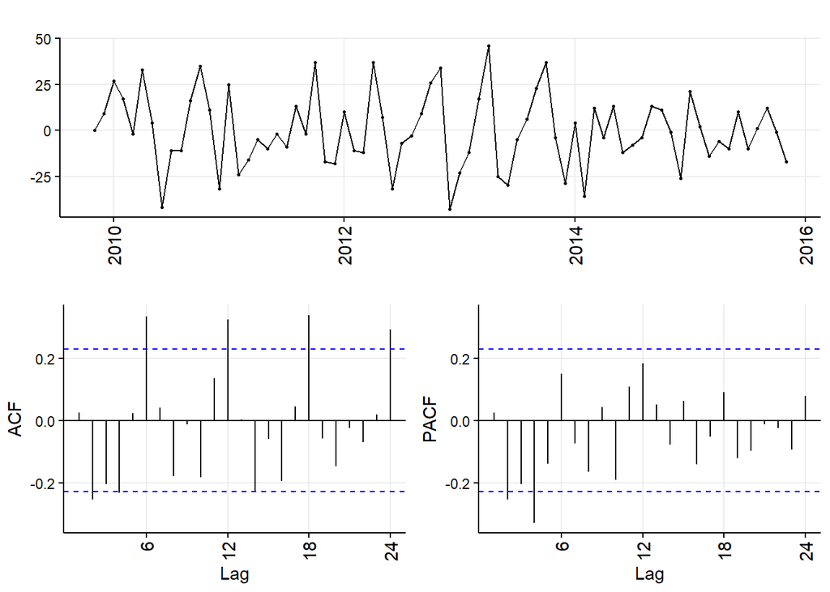

```r
# Monthly data
Parvo_ts_dataM %>% diff() %>% ggtsdisplay(theme = themeVB) # Assess differenced ts and ACF and PACF plots.
```

The PACF plot for the weekly data has a fast decay with significant partial autocorrelation in the first two lags significant. This suggests AR(2). The PACF plot for the monthly data limited partial autocorrelation significant. This suggests AR(0-2) for the monthly ARIMA model.

[Click here for more information about selected parameters for ARIMA models…](https://rpubs.com/riazakhan94/arima_with_example)

[…and here.](https://support.minitab.com/en-us/minitab/18/help-and-how-to/modeling-statistics/time-series/how-to/partial-autocorrelation/interpret-the-results/partial-autocorrelation-function-pacf/)

For seasonality, there are spikes in the weekly ACF at approximately 2 years, indicating MA(1-3). There are 3 spikes around 6 months in the PACF, indicating AR(1-3).

For seasonality in the monthly data, there are consistent spikes at 6 months, suggesting MA(2), and limted spikes in the PACF, suggesting AR(0-1).

## 2. Fit an ARIMA model

An ARIMA model with a seasonal component can be called a SARIMA model.

Based on exploratory analysis, we expect that the structure is:

Weekly ARIMA: (2, 1, 1) (1-3, 0, 1-3) [52]

Monthly ARIMA: (0-2, 1, 0-2) (0-1, 0, 2) [12]

We then fit other plausible models based on the exploratory analysis. We select the final model based on lowest AIC.

```r
Auto_Arima = auto.arima(Parvo_ts_data)
summary(Auto_Arima)
```

```
## Series: Parvo_ts_data
## ARIMA(3,1,1)(1,0,0)[52] with drift
##
## Coefficients:
```

```
##           ar1      ar2      ar3    ma1    sar1    drift
##       -0.2209  -0.0671  -0.0155  -0.28  0.1117  -0.0926
## s.e.   0.0015      NaN   0.0008    NaN     NaN   0.1475
##
## sigma^2 estimated as 18.9:  log likelihood=-909.94
## AIC=1833.87   AICc=1834.24   BIC=1860.16
##
## Training set error measures:
##                     ME     RMSE      MAE  MPE MAPE      MASE         ACF1
## Training set 0.1599227 4.299481 3.303407 -Inf  Inf 0.5512612 -0.004982498
```

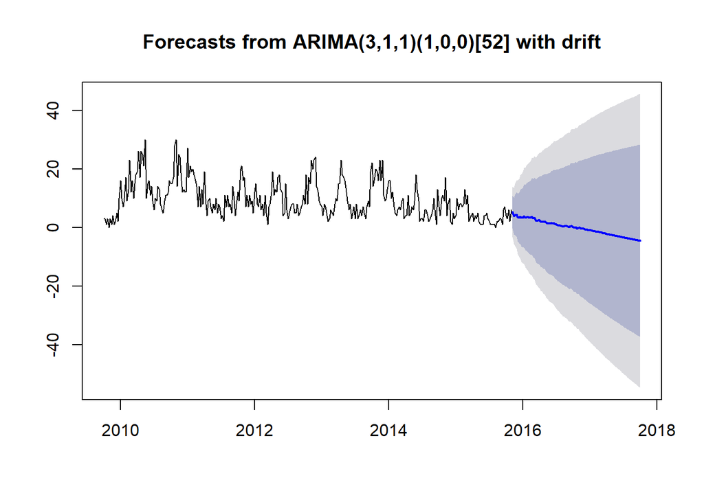

```r
plot(forecast(Auto_Arima, 100))
```

```r
confint(Auto_Arima)
```

```
##             2.5 %      97.5 %
## ar1   -0.22377041 -0.21806631
## ar2           NaN         NaN
## ar3   -0.01703369 -0.01401343
## ma1           NaN         NaN
## sar1          NaN         NaN
## drift -0.38169498  0.19639837
```

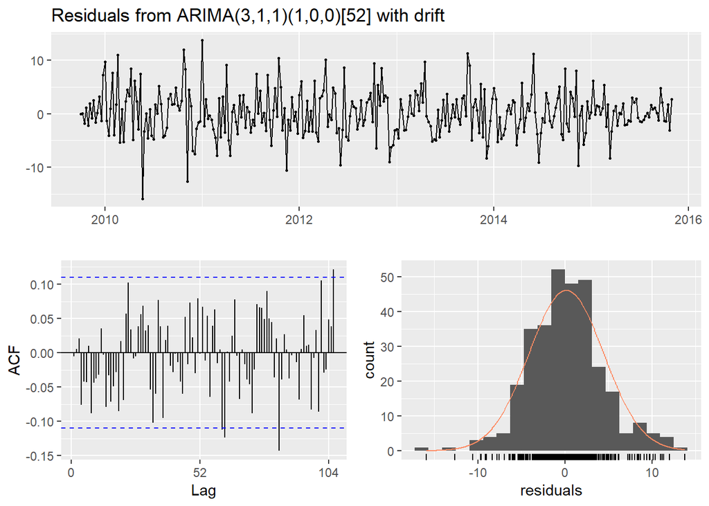

```
##
##  Ljung-Box test
##
## data:  Residuals from ARIMA(3,1,1)(1,0,0)[52] with drift
## Q* = 65.322, df = 57, p-value = 0.2101
##
## Model df: 6.   Total lags used: 63
```

```r
checkresiduals(Auto_Arima)
```

The automated function has slected a model with structure ARIMA(3,1,1)(1,0,0)[52] with drift. The drift term creates a trend in the forecast time-series.

```r
Auto_ArimaM = auto.arima(Parvo_ts_dataM)
summary(Auto_ArimaM)
```

```
## Series: Parvo_ts_dataM
## ARIMA(2,1,1)(2,0,0)[12]
##
## Coefficients:
##          ar1      ar2      ma1    sar1    sar2
##       0.7976  -0.2931  -0.9028  0.1562  0.2939
## s.e.  0.1445   0.1349   0.1120  0.1241  0.1361
##
## sigma^2 estimated as 289.2:  log likelihood=-309.67
## AIC=631.33   AICc=632.61   BIC=645.08
##
## Training set error measures:
##                      ME     RMSE      MAE       MPE     MAPE      MASE
## Training set -0.8649256 16.30082 13.35613 -43.75883 66.48852 0.6088825
##                   ACF1
## Training set -0.016731
```

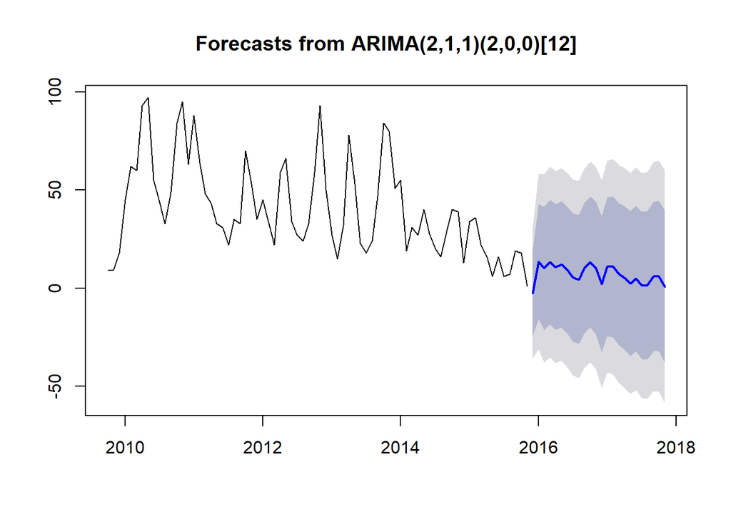

```r
plot(forecast(Auto_ArimaM,24))
```

```r
confint(Auto_ArimaM)
```

```
##            2.5 %      97.5 %
## ar1   0.51445880  1.08072576
## ar2  -0.55744923 -0.02881166
## ma1  -1.12243907 -0.68326091
## sar1 -0.08702874  0.39948777
## sar2  0.02719195  0.56070413
```

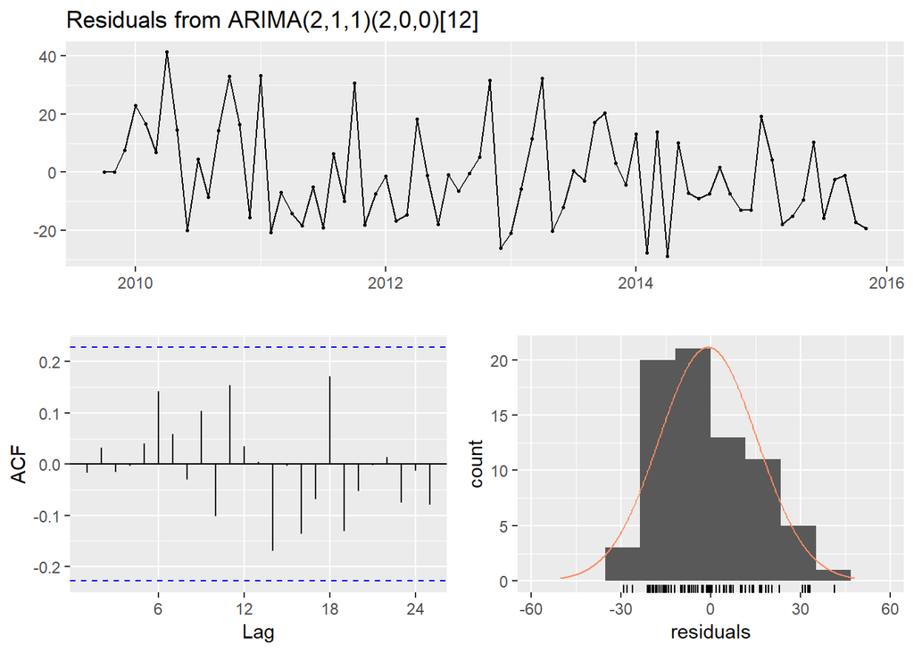

```
##
##  Ljung-Box test
##
## data:  Residuals from ARIMA(2,1,1)(2,0,0)[12]
## Q* = 9.0685, df = 10, p-value = 0.5256
##
## Model df: 5.   Total lags used: 15
```

```r
checkresiduals(Auto_ArimaM)
```

The automated functions suggest:

Weekly ARIMA (3,1,1)(1,0,0)[52] with drift, AICc=1834.24

Monthly ARIMA (2,1,1)(2,0,0)[12], AICc=632.61

We test other, simpler model structures which are still within the estimated parameters from time series exploration:

```r
### Weekly time series models
## Weekly ARIMA: (2, 1, 1) (1-3, 0, 1-3) [52]
## fitted: (3,1,1)(1,0,0)[52] with drift, AICc=1834.24

fit1 = Arima(Parvo_ts_data, order = c(2, 1, 1), seasonal = c(1, 0, 0))
summary(fit1)
```

```
## Series: Parvo_ts_data
## ARIMA(2,1,1)(1,0,0)[52]
##
## Coefficients:
##          ar1     ar2      ma1    sar1
##       0.4620  0.3052  -0.9855  0.1169
## s.e.  0.0559  0.0558   0.0133  0.0603
##
## sigma^2 estimated as 18.08:  log likelihood=-904.79
## AIC=1819.58   AICc=1819.77   BIC=1838.36
##
## Training set error measures:
##                       ME     RMSE     MAE  MPE MAPE      MASE        ACF1
## Training set -0.07217848 4.217939 3.29608 -Inf  Inf 0.5500386 -0.03497213
```

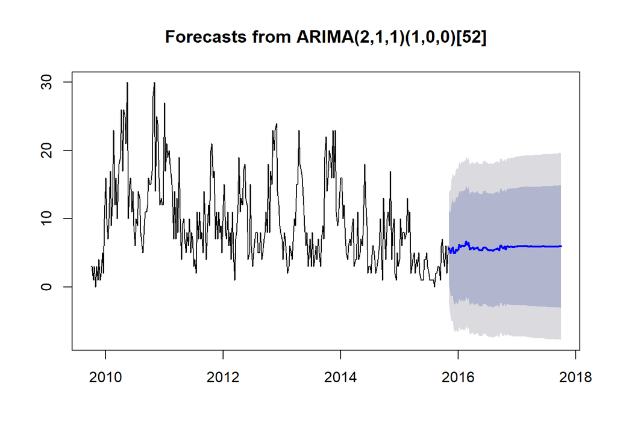

```r
plot(forecast(fit1,100))
```

```r
confint(fit1)
```

```
##             2.5 %     97.5 %
## ar1   0.352490442  0.5715407
## ar2   0.195782287  0.4145399
## ma1  -1.011501759 -0.9594912
## sar1 -0.001165745  0.2350279
```

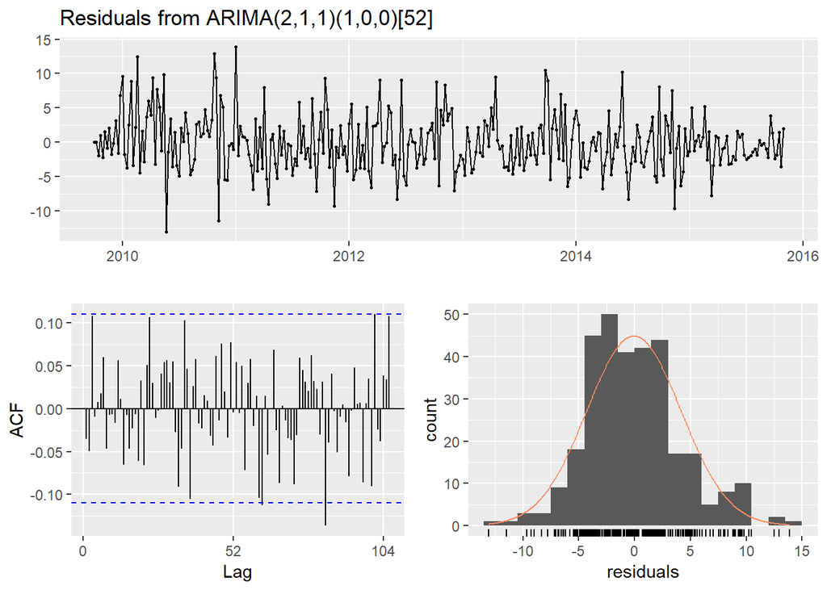

```
##
##  Ljung-Box test
##
## data:  Residuals from ARIMA(2,1,1)(1,0,0)[52]
## Q* = 60.566, df = 59, p-value = 0.4191
##
## Model df: 4.   Total lags used: 63
```

```r
checkresiduals(fit1)
```

```r
fit2 = Arima(Parvo_ts_data, order = c(2, 1, 1), seasonal = c(0, 0, 1))
summary(fit2)
```

```
## Series: Parvo_ts_data
## ARIMA(2,1,1)(0,0,1)[52]
##
## Coefficients:
##           ar1      ar2      ma1    sma1
##       -0.3206  -0.1059  -0.1822  0.1082
## s.e.   0.6803   0.3097   0.6928  0.0586
##
## sigma^2 estimated as 18.78:  log likelihood=-910.18
## AIC=1830.36   AICc=1830.55   BIC=1849.14
##
## Training set error measures:
##                      ME     RMSE      MAE  MPE MAPE      MASE         ACF1
## Training set 0.00654623 4.299126 3.302973 -Inf  Inf 0.5511889 -0.000116437
```

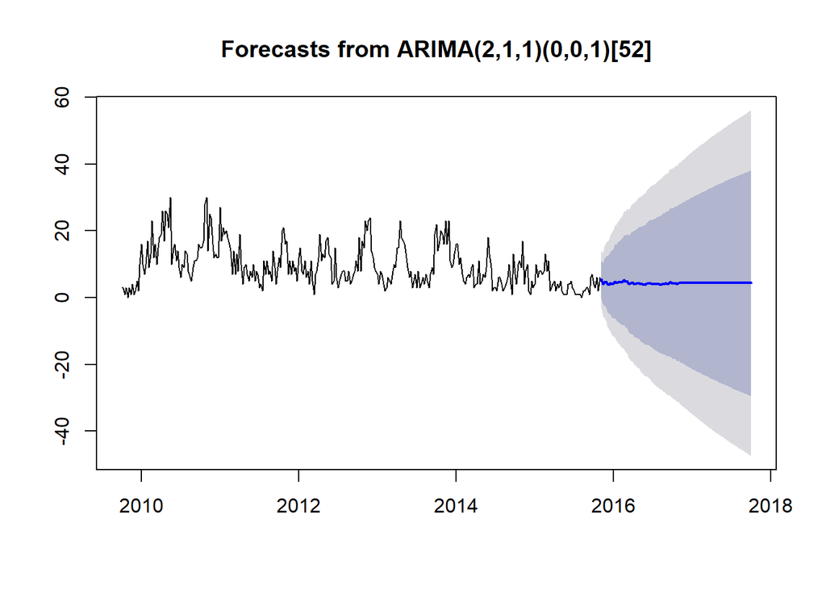

```r
plot(forecast(fit2,100))
```

```r
confint(fit2)
```

```
##             2.5 %    97.5 %
## ar1  -1.654048780 1.0127577
## ar2  -0.712904310 0.5010499
## ma1  -1.540119325 1.1757347
## sma1 -0.006698454 0.2230720
```

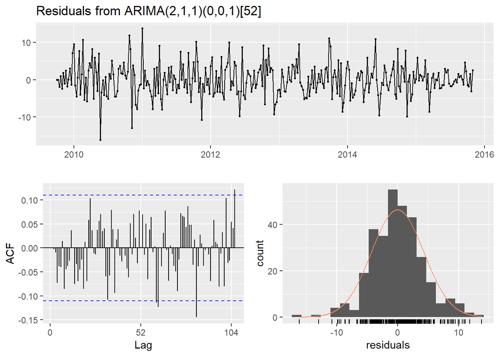

```
##
##  Ljung-Box test
##
## data:  Residuals from ARIMA(2,1,1)(0,0,1)[52]
## Q* = 65.577, df = 59, p-value = 0.2594
##
## Model df: 4.   Total lags used: 63
```

```r
checkresiduals(fit2)
```

```r
fit3 = Arima(Parvo_ts_data, order = c(2, 1, 1), seasonal = c(1, 0, 0), include.drift = T)  # *** This model is the best weekly model
summary(fit3)
```

```
## Series: Parvo_ts_data
## ARIMA(2,1,1)(1,0,0)[52] with drift
##
## Coefficients:
##          ar1     ar2      ma1    sar1    drift
##       0.4620  0.3023  -1.0000  0.1123  -0.0228
## s.e.  0.0271  0.0347   0.0095  0.0380   0.0111
##
## sigma^2 estimated as 17.89:  log likelihood=-903.6
## AIC=1819.2   AICc=1819.47   BIC=1841.73
##
## Training set error measures:
##                    ME     RMSE      MAE  MPE MAPE     MASE        ACF1
## Training set 0.239633 4.188925 3.252542 -Inf  Inf 0.542773 -0.03663276
```

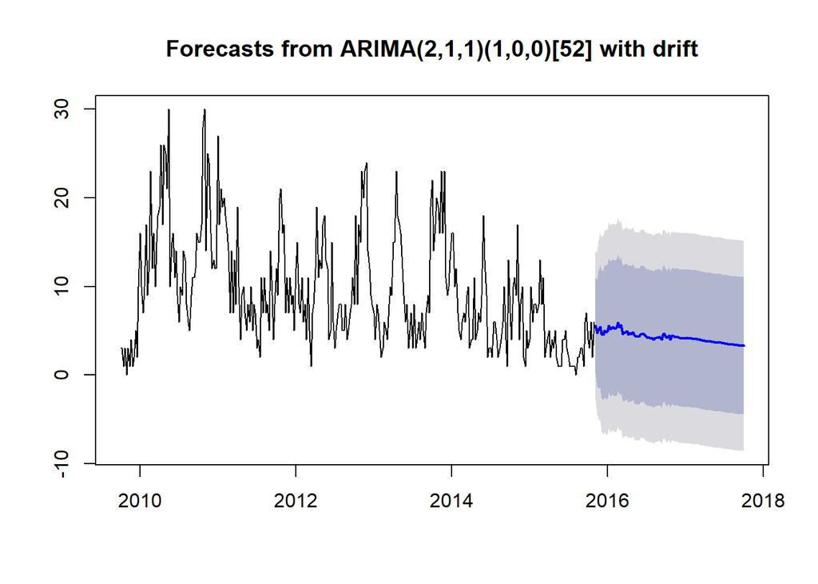

```r
plot(forecast(fit3,100))
```

```r
confint(fit3)
```

```
##             2.5 %        97.5 %
## ar1    0.40892020  0.5151448697
## ar2    0.23420620  0.3704037654
## ma1   -1.01863686 -0.9813614681
## sar1   0.03777440  0.1869119301
## drift -0.04465446 -0.0009709036
```

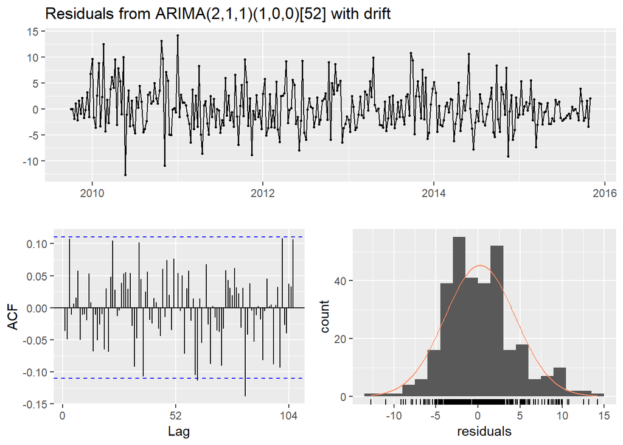

```
##
##  Ljung-Box test
##
## data:  Residuals from ARIMA(2,1,1)(1,0,0)[52] with drift
## Q* = 60.48, df = 58, p-value = 0.3864
##
## Model df: 5.   Total lags used: 63
```

```r
checkresiduals(fit3)
```

```r
### monthly time series models
## Monthly ARIMA: (0-2, 1, 0-2) (0-1, 0, 2) [12]
## Auto fitted: (2,1,1)(2,0,0)[12], AICc=632.61

fit4 = Arima(Parvo_ts_dataM, order = c(1, 1, 1), seasonal = c(1, 0, 0))
summary(fit4)
```

```
## Series: Parvo_ts_dataM
## ARIMA(1,1,1)(1,0,0)[12]
##
## Coefficients:
##          ar1      ma1    sar1
##       0.6992  -0.9741  0.3425
## s.e.  0.1237   0.0648  0.1195
##
## sigma^2 estimated as 315.6:  log likelihood=-313.24
## AIC=634.47   AICc=635.06   BIC=643.63
##
## Training set error measures:
##                     ME     RMSE      MAE       MPE     MAPE      MASE
## Training set -0.478025 17.27936 14.34423 -48.01381 72.26332 0.6539282
##                 ACF1
## Training set 0.10414
```

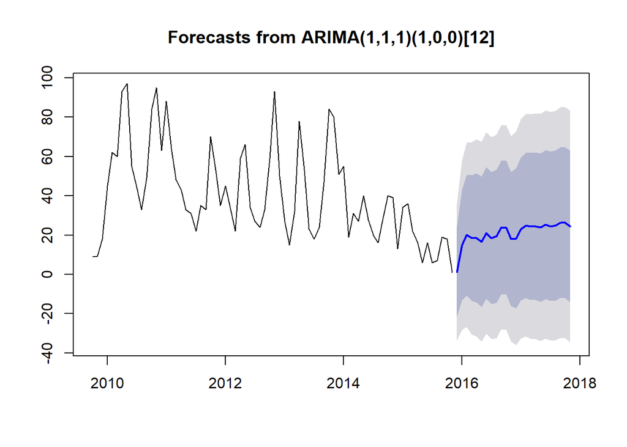

```r
plot(forecast(fit4, 24))
```

```r
confint(fit4)
```

```
##           2.5 %     97.5 %
## ar1   0.4567312  0.9417214
## ma1  -1.1012459 -0.8470436
## sar1  0.1083085  0.5766908
```

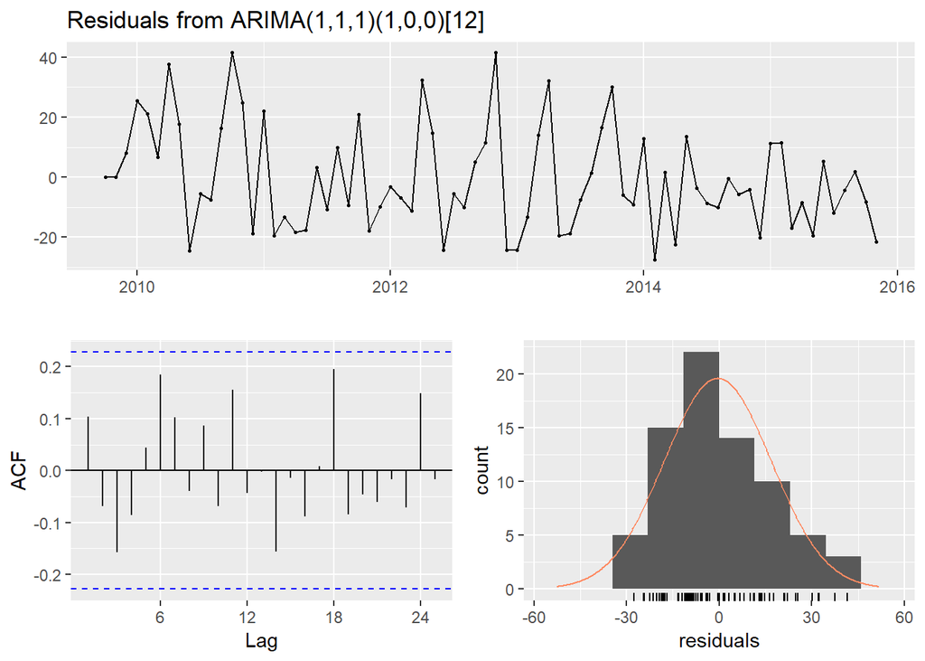

```
##
##  Ljung-Box test
##
## data:  Residuals from ARIMA(1,1,1)(1,0,0)[12]
## Q* = 13.434, df = 12, p-value = 0.3383
##
## Model df: 3.   Total lags used: 15
```

```r
checkresiduals(fit4)
```

```r
fit5 = Arima(Parvo_ts_dataM, order = c(2, 1, 1), seasonal = c(0, 0, 1))
summary(fit5)
```

```
## Series: Parvo_ts_dataM
## ARIMA(2,1,1)(0,0,1)[12]
##
## Coefficients:
##          ar1      ar2      ma1    sma1
##       0.7398  -0.2685  -0.9041  0.1761
## s.e.  0.1297   0.1299   0.0853  0.1156
##
## sigma^2 estimated as 317.3:  log likelihood=-312.43
## AIC=634.87   AICc=635.77   BIC=646.32
##
## Training set error measures:
##                      ME     RMSE      MAE       MPE     MAPE      MASE
## Training set -0.6784402 17.20082 13.94435 -46.66232 69.09401 0.6356984
##                     ACF1
## Training set -0.01497955
```

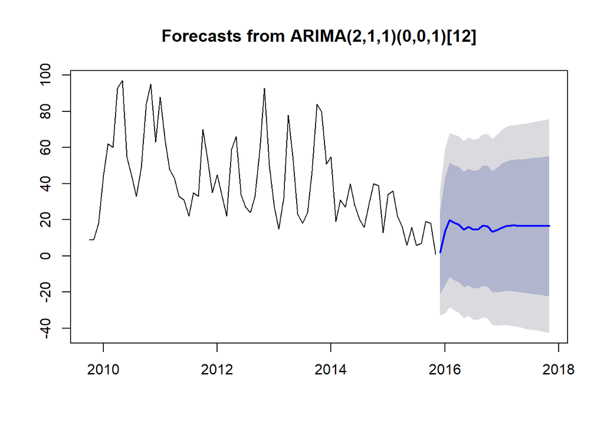

```r
plot(forecast(fit5, 24))
```

```r
confint(fit5)
```

```
##            2.5 %      97.5 %
## ar1   0.48560490  0.99392851
## ar2  -0.52298029 -0.01392542
## ma1  -1.07138134 -0.73683305
## sma1 -0.05048666  0.40260207
```

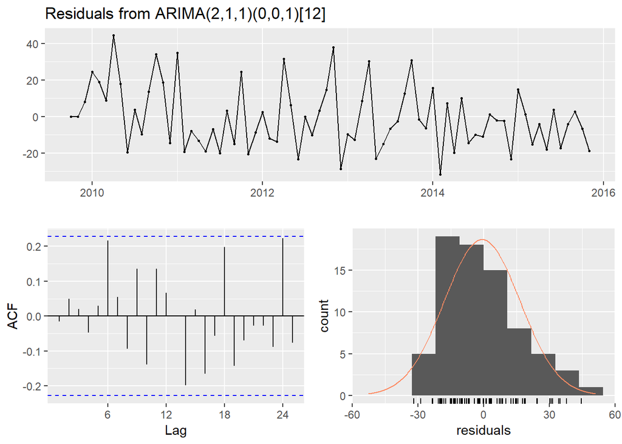

```
##
##  Ljung-Box test
##
## data:  Residuals from ARIMA(2,1,1)(0,0,1)[12]
## Q* = 14.416, df = 11, p-value = 0.2108
##
## Model df: 4.   Total lags used: 15
```

```r
checkresiduals(fit5)
```

```r
fit6 = Arima(Parvo_ts_dataM, order = c(2, 1, 1), seasonal = c(2, 0, 0), include.drift = T)
summary(fit6)
```

```
## Series: Parvo_ts_dataM
## ARIMA(2,1,1)(2,0,0)[12] with drift
##
## Coefficients:
##          ar1      ar2      ma1    sar1    sar2    drift
##       0.8313  -0.2963  -1.0000  0.1516  0.2841  -0.5061
## s.e.  0.1186   0.1278   0.0381  0.1222  0.1353   0.2061
##
## sigma^2 estimated as 279.2:  log likelihood=-308.64
## AIC=631.29   AICc=633.01   BIC=647.32
##
## Training set error measures:
##                    ME     RMSE      MAE       MPE     MAPE      MASE
## Training set 1.927427 15.89803 12.60622 -36.89273 64.13716 0.5746953
##                     ACF1
## Training set -0.02974478
```

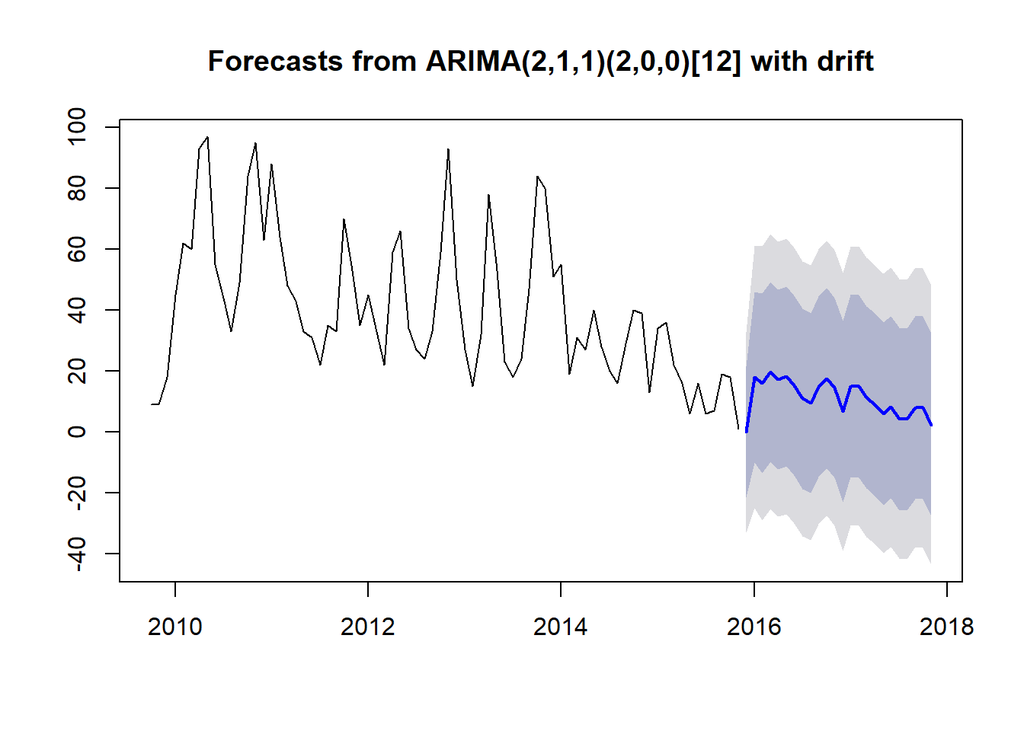

```r
plot(forecast(fit6, 24))
```

```r
confint(fit6)
```

```
##             2.5 %      97.5 %
## ar1    0.59891581  1.06376762
## ar2   -0.54670833 -0.04585074
## ma1   -1.07463500 -0.92535175
## sar1  -0.08791284  0.39101991
## sar2   0.01888095  0.54933999
## drift -0.91008622 -0.10210976
```

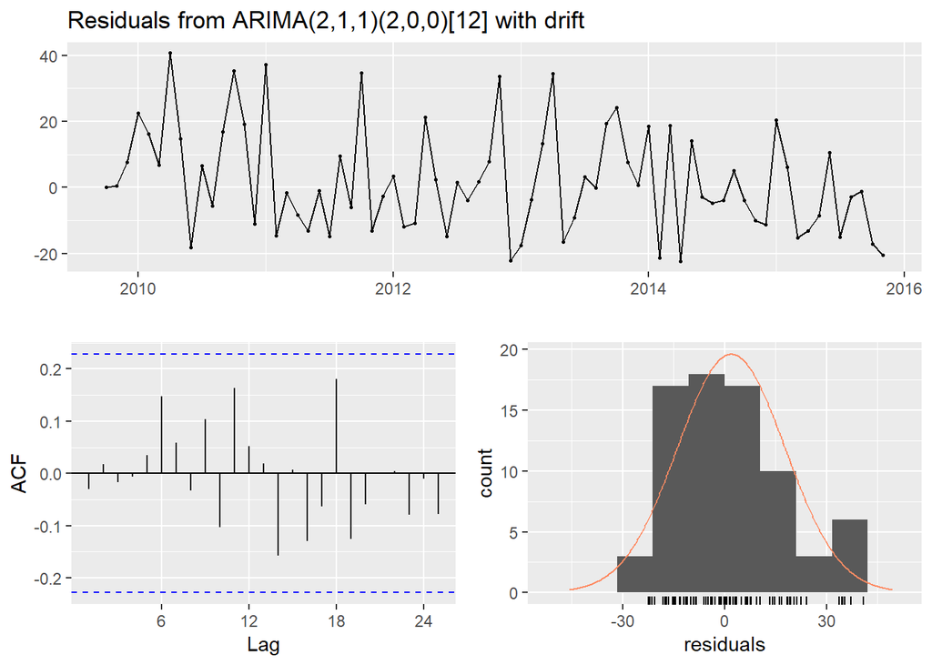

```
##
##  Ljung-Box test
##
## data:  Residuals from ARIMA(2,1,1)(2,0,0)[12] with drift
## Q* = 9.2198, df = 9, p-value = 0.4172
##
## Model df: 6.   Total lags used: 15
```

```r
checkresiduals(fit6)
```

```r
fit7 = Arima(Parvo_ts_dataM, order = c(1, 1, 0), seasonal = c(1, 0, 0))
summary(fit7)
```

```
## Series: Parvo_ts_dataM
## ARIMA(1,1,0)(1,0,0)[12]
##
## Coefficients:
##           ar1    sar1
##       -0.0276  0.3670
## s.e.   0.1184  0.1136
##
## sigma^2 estimated as 350.6:  log likelihood=-317.31
## AIC=640.63   AICc=640.97   BIC=647.5
##
## Training set error measures:
##                      ME     RMSE      MAE       MPE     MAPE     MASE
## Training set -0.3311234 18.34056 14.86254 -33.96177 64.98723 0.677557
##                      ACF1
## Training set -0.003681255
```

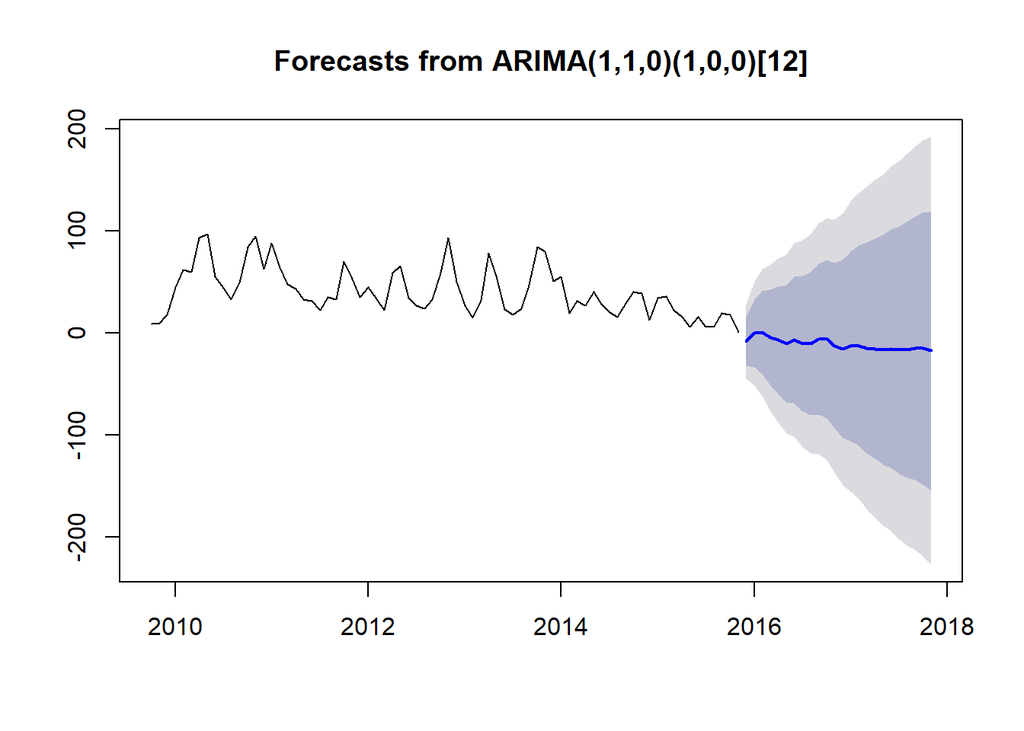

```r
plot(forecast(fit7, 24))
```

```r
confint(fit7)
```

```
##           2.5 %    97.5 %
## ar1  -0.2596615 0.2044482
## sar1  0.1443652 0.5895377
```

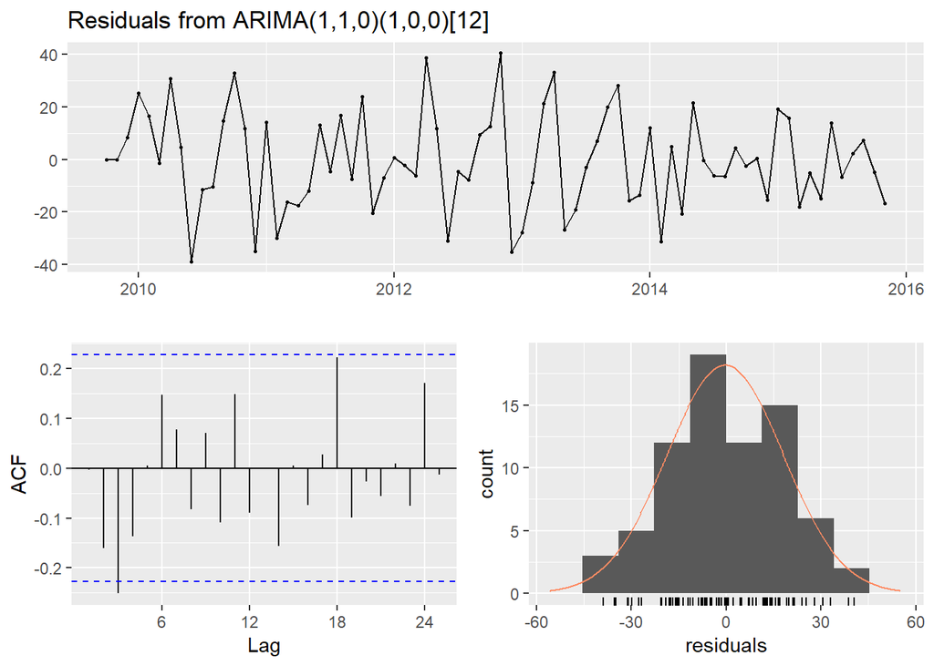

```
##
##  Ljung-Box test
##
## data:  Residuals from ARIMA(1,1,0)(1,0,0)[12]
## Q* = 17.913, df = 13, p-value = 0.1609
##
## Model df: 2.   Total lags used: 15
```

```r
checkresiduals(fit7)
```

The final models are ‘fit3’ for the weekly time-series and the auto-fitted model for the monthly time-series. Each has the lowest AICc of tested models, and produces a plausible forecast of the original time series. The residuals are reasonably Normaly distributed and the ACF plot of the residuals and Ljung-Box tests suggest that the residuals are time independent.

# Multivariate forecasting with time-series

In this section, we first consider how to modify an ARIMA model to include a predictor (other than the univariate time-series). We use the example of rainfall as a predictor of parvovirus events, and select monthly rainfall at Mudgee, NSW (mean centre of parvovirus event data).

1. Prepare, describe and decompose the rainfall series.

```r
dataSource_Rain = getURL("https://raw.githubusercontent.com/vbrookes/Timeseries_analysis/master/Mudgee_Monthly_rainfall.csv")
RainfallM = read.csv(text = dataSource_Rain, header = T)
summary(RainfallM)
```

```
##         Date       Rain_mm
##  1/01/2010: 1   Min.   :  5.40
##  1/01/2011: 1   1st Qu.: 24.80
##  1/01/2012: 1   Median : 47.50
##  1/01/2013: 1   Mean   : 56.45
##  1/01/2014: 1   3rd Qu.: 75.40
##  1/01/2015: 1   Max.   :214.40
##  (Other)  :68
```

```r
str(RainfallM)
```

```
## 'data.frame':    74 obs. of  2 variables:
##  $ Date   : Factor w/ 74 levels "1/01/2010","1/01/2011",..: 55 62 69 1 7 13 19 25 31 37 ...
##  $ Rain_mm: num  34 16 121.4 46.4 90 ...
```

```r
head(RainfallM)
```

```
##        Date Rain_mm
## 1 1/10/2009    34.0
## 2 1/11/2009    16.0
## 3 1/12/2009   121.4
## 4 1/01/2010    46.4
## 5 1/02/2010    90.0
## 6 1/03/2010    89.0
```

```r
tail(RainfallM)
```

```
##         Date Rain_mm
## 69 1/06/2015   55.20
## 70 1/07/2015   61.60
## 71 1/08/2015   30.40
## 72 1/09/2015    5.40
## 73 1/10/2015   44.00
## 74 1/11/2015  101.45
```

```r
RainfallM$Date = as.character(RainfallM$Date, format = "%d/%m/%Y")
RainfallM$Date = as.Date(RainfallM$Date, "%d/%m/%Y")

RainfallM$byMonth = cut(RainfallM$Date, breaks="1 month")
RainfallM$byMonth <-  as.Date(RainfallM$byMonth, format = "%Y-%m-%d")

# summary
summary(RainfallM)
```

```
##       Date               Rain_mm          byMonth
##  Min.   :2009-10-01   Min.   :  5.40   Min.   :2009-10-01
##  1st Qu.:2011-04-08   1st Qu.: 24.80   1st Qu.:2011-04-08
##  Median :2012-10-16   Median : 47.50   Median :2012-10-16
##  Mean   :2012-10-15   Mean   : 56.45   Mean   :2012-10-15
##  3rd Qu.:2014-04-23   3rd Qu.: 75.40   3rd Qu.:2014-04-23
##  Max.   :2015-11-01   Max.   :214.40   Max.   :2015-11-01
```

```r
# check structure
str(RainfallM)
```

```
## 'data.frame':    74 obs. of  3 variables:
##  $ Date   : Date, format: "2009-10-01" "2009-11-01" ...
##  $ Rain_mm: num  34 16 121.4 46.4 90 ...
##  $ byMonth: Date, format: "2009-10-01" "2009-11-01" ...
```

```r
# Check length
length(RainfallM$Dates)
```

```
## [1] 0
```

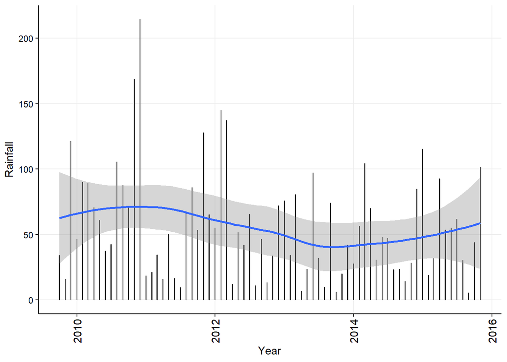

```r
ggplot(RainfallM, aes(x = byMonth, y = Rain_mm, group = 1)) +
  geom_bar(stat="identity", width = 0.5, colour = "black") +
  stat_smooth(aes(y = Rain_mm), method='auto', level=0.95) +
  themeVB +
  scale_x_date() +
  xlab("Year") +
  ylab("Rainfall")
```

```r
Rainfall_ts_data <- ts(RainfallM$Rain_mm, start = c(2009, 10), frequency =12)

Decompose_tsRainM <- decompose(Rainfall_ts_data)
summary(Decompose_tsRainM)
```

```
##          Length Class  Mode
## x        74     ts     numeric
## seasonal 74     ts     numeric
## trend    74     ts     numeric
## random   74     ts     numeric
## figure   12     -none- numeric
## type      1     -none- character
```

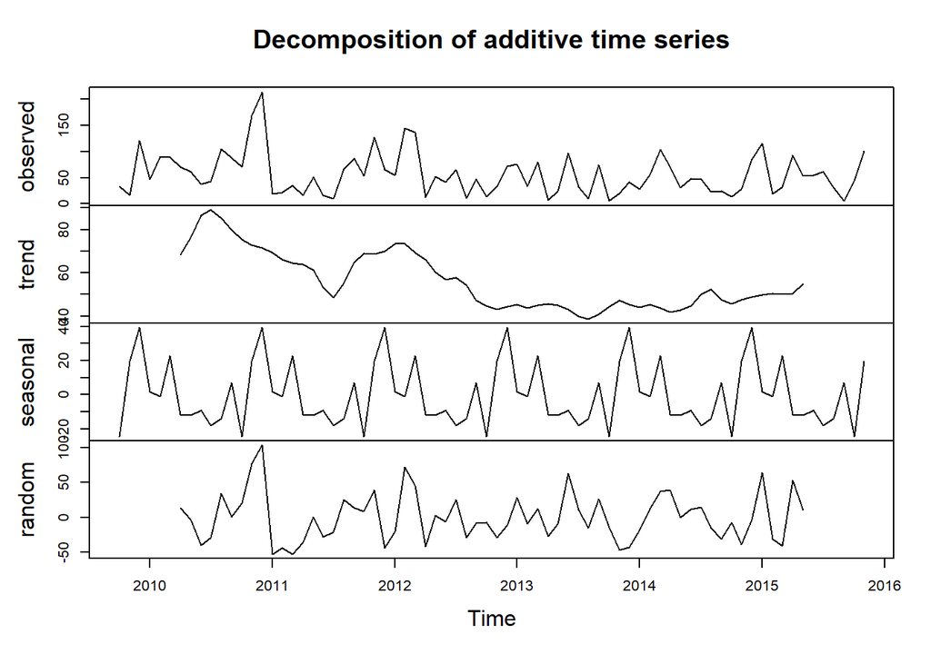

```r
plot(Decompose_tsRainM)
```

Quantitatively assess the trend, seasonality and stationarity of the data.

```r
# Assess trend and seasonality
fit_Rain_dataM = lm(Rainfall_ts_data ~ time(Rainfall_ts_data) + factor(cycle(Rainfall_ts_data)))
summary(fit_Rain_dataM)
```

```
##
## Call:
## lm(formula = Rainfall_ts_data ~ time(Rainfall_ts_data) + factor(cycle(Rainfall_ts_data)))
##
## Residuals:
##    Min     1Q Median     3Q    Max
## -66.87 -28.45  -4.26  21.10 108.41
##
## Coefficients:
##                                     Estimate Std. Error t value Pr(>|t|)
## (Intercept)                       8079.93470 5220.28469   1.548   0.1268
## time(Rainfall_ts_data)              -3.98680    2.59392  -1.537   0.1295
## factor(cycle(Rainfall_ts_data))2     4.79890   22.76256   0.211   0.8337
## factor(cycle(Rainfall_ts_data))3    23.69447   22.76564   1.041   0.3021
## factor(cycle(Rainfall_ts_data))4   -10.80997   22.77077  -0.475   0.6367
## factor(cycle(Rainfall_ts_data))5   -10.11107   22.77795  -0.444   0.6587
## factor(cycle(Rainfall_ts_data))6    -5.56883   22.78718  -0.244   0.8078
## factor(cycle(Rainfall_ts_data))7   -11.44660   22.79846  -0.502   0.6174
## factor(cycle(Rainfall_ts_data))8   -13.04770   22.81178  -0.572   0.5694
## factor(cycle(Rainfall_ts_data))9     0.08453   22.82713   0.004   0.9971
## factor(cycle(Rainfall_ts_data))10  -21.79568   21.94315  -0.993   0.3245
## factor(cycle(Rainfall_ts_data))11   15.72798   21.95060   0.717   0.4764
## factor(cycle(Rainfall_ts_data))12   43.16777   22.76256   1.896   0.0626 .
## ---
## Signif. codes:  0 '***' 0.001 '**' 0.01 '*' 0.05 '.' 0.1 ' ' 1
##
## Residual standard error: 39.42 on 61 degrees of freedom
## Multiple R-squared:  0.2273, Adjusted R-squared:  0.07531
## F-statistic: 1.495 on 12 and 61 DF,  p-value: 0.1507
```

```r
confint(fit_Rain_dataM)
```

```
##                                          2.5 %       97.5 %
## (Intercept)                       -2358.669697 18518.539091
## time(Rainfall_ts_data)               -9.173656     1.200063
## factor(cycle(Rainfall_ts_data))2    -40.717660    50.315460
## factor(cycle(Rainfall_ts_data))3    -21.828250    69.217183
## factor(cycle(Rainfall_ts_data))4    -56.342943    34.723008
## factor(cycle(Rainfall_ts_data))5    -55.658402    35.436267
## factor(cycle(Rainfall_ts_data))6    -51.134624    39.996954
## factor(cycle(Rainfall_ts_data))7    -57.034937    34.141733
## factor(cycle(Rainfall_ts_data))8    -58.662667    32.567263
## factor(cycle(Rainfall_ts_data))9    -45.561143    45.730205
## factor(cycle(Rainfall_ts_data))10   -65.673724    22.082360
## factor(cycle(Rainfall_ts_data))11   -28.164962    59.620922
## factor(cycle(Rainfall_ts_data))12    -2.348793    88.684327
```

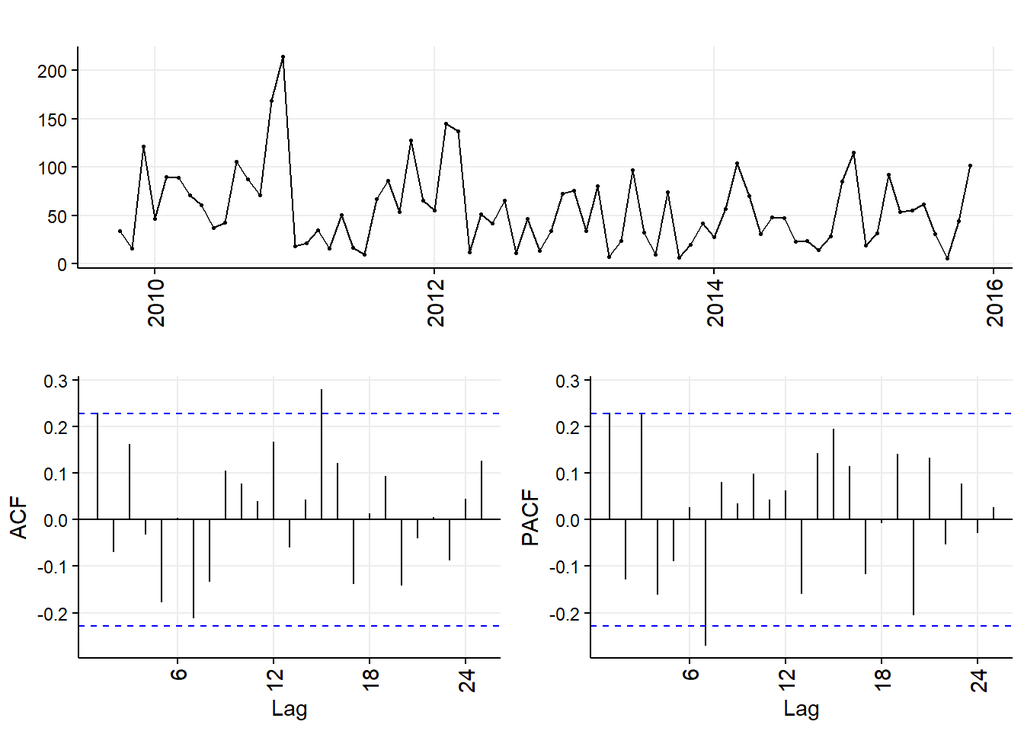

```r
# Tests for stationarity
Rainfall_ts_data %>% ggtsdisplay(theme = themeVB)
```

```r
# We  run `ndiffs` and `nsdiffs` (seasonal) from the `forecast` package to assess how many first differences are needed to induce stationarity.
ndiffs(Rainfall_ts_data)
```

```
## [1] 0
```

```r
nsdiffs(Rainfall_ts_data)
```

```
## [1] 0
```

```r
## Monthly time-series tests for stationarity
# 1.
Box.test(Rainfall_ts_data, lag = 12, type="Ljung-Box")
```

```
##
##  Box-Ljung test
##
## data:  Rainfall_ts_data
## X-squared = 18.627, df = 12, p-value = 0.09794
```

```r
# 2.
adf.test(Rainfall_ts_data, alternative = "stationary", k = 24)
```

```
##
##  Augmented Dickey-Fuller Test
##
## data:  Rainfall_ts_data
## Dickey-Fuller = -0.071898, Lag order = 24, p-value = 0.99
## alternative hypothesis: stationary
```

```r
# 3.
kpss.test(Rainfall_ts_data, null = 'Trend')
```

```
##
##  KPSS Test for Trend Stationarity
##
## data:  Rainfall_ts_data
## KPSS Trend = 0.052388, Truncation lag parameter = 3, p-value = 0.1
```

```r
kpss.test(Rainfall_ts_data, null = 'Level')
```

```
##
##  KPSS Test for Level Stationarity
##
## data:  Rainfall_ts_data
## KPSS Level = 0.30441, Truncation lag parameter = 3, p-value = 0.1
```

3. We can therefore, use the raw rainfall series in the model.

```r
fit <- auto.arima(Parvo_ts_dataM, xreg=Rainfall_ts_data)
summary(fit)
```

```
## Series: Parvo_ts_dataM
## Regression with ARIMA(2,1,1)(2,0,0)[12] errors
##
## Coefficients:
##          ar1     ar2      ma1    sar1    sar2     xreg
##       0.8769  -0.305  -0.9209  0.1032  0.3378  -0.1057
## s.e.  0.1300   0.131   0.0810  0.1204  0.1303   0.0393
##
## sigma^2 estimated as 266.7:  log likelihood=-306.4
## AIC=626.81   AICc=628.53   BIC=642.84
##
## Training set error measures:
##                      ME     RMSE      MAE       MPE     MAPE      MASE
## Training set -0.8473194 15.53964 12.91691 -37.30511 61.52266 0.5888593
##                    ACF1
## Training set -0.0273563
```

```r
confint(fit)
```

```
##           2.5 %      97.5 %
## ar1   0.6221184  1.13175374
## ar2  -0.5617401 -0.04830879
## ma1  -1.0796567 -0.76214332
## sar1 -0.1328496  0.33927111
## sar2  0.0823451  0.59329433
## xreg -0.1827247 -0.02877087
```

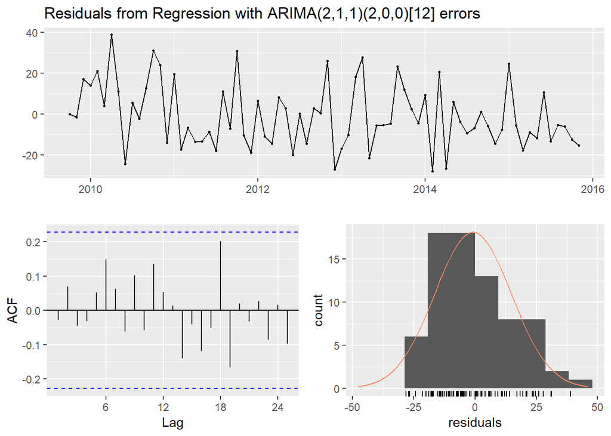

```
##
##  Ljung-Box test
##
## data:  Residuals from Regression with ARIMA(2,1,1)(2,0,0)[12] errors
## Q* = 8.5041, df = 9, p-value = 0.4842
##
## Model df: 6.   Total lags used: 15
```

```r
checkresiduals(fit)
```

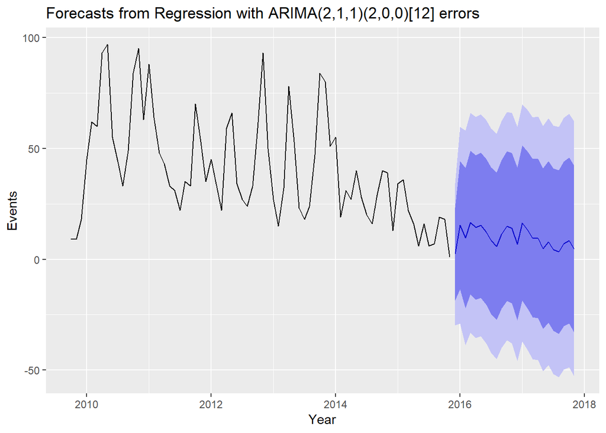

```r
fcast <- forecast(fit, xreg=rep(mean(Rainfall_ts_data),24))

autoplot(fcast) + xlab("Year") + ylab("Events")
```

### Vector auto-regression (VAR) models

In these models, there no assumptions about the direction of prediction and the potential influence of one time-series on the other is symmetrical. Therefore, parvo events could predict rainfall, or rainfall could predict parvo events. Obviously, this is a ridiculous suggestion in this context, but it can be useful to give insights in other contexts. Examples could include exploration of the direction of disease spread between two populations (we want to explore causation). It is also useful for forecasting when we simply want a mathematically useful predictive model (we have made a prior causal model and are interested in predictions in one direction).

Initially we examine the correlation between lags of monthly parvo reports and rainfall using cross-correlation plots.

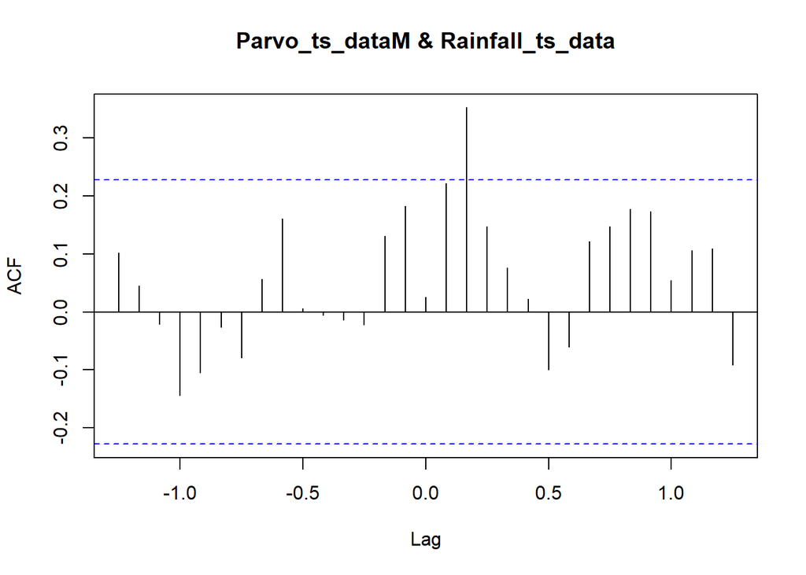

```r
ccf(Parvo_ts_dataM, Rainfall_ts_data, type = 'correlation')
```

There appears to be cross-correlation between parvo events and rainfall at +2 months (rainfall leads parvo events on this side of the plot… which is also biologically sensible :-)).

The model we are going to fit is a VAR model (no I or MA), so data need to be differenced to induce stationarity if necessary prior to model fitting. A predictive equation is fitted for each parvo events and rainfall. The equations are symmetrical (same number of predictor variables and lags).

```r
# Difference Parvo data because model is VARMA (no I)
ParvoM_diff = diff(Parvo_ts_dataM)

Differenced_data <- cbind(ParvoM_diff, Rainfall_ts_data) # Combine in a dataframe with the rainfall data.
Differenced_data[is.na(Differenced_data)] <- 0 # Convert first value from NA to 0
```

In our example, we have two variables (parvo events and rainfall, k = 2). We need to determine the number of AR lags (p) for each equation in the model. We use the `VARselect` function to estimate the p order in the model.

The output gives: 1. AIC - For VAR models, we the BIC (SC) is preferable, because AIC tends to select large numbers of lags. 2. HQ - Hannan-Quinn criterion 3. SC - another name for the BIC (SC stands for Schwarz Criterion, after Gideon Schwarz who proposed it) 4. FPE - “Final Prediction Error” criterion.

The number of coefficients estimated in a VAR = k+pk<sup>2</sup>. Note that because every variable is assumed to influence every other variable in the system, it makes a direct interpretation of the estimated coefficients difficult.

```r
# estimate orders for AR(p) and MA(q) between parvo events and rainfall
library(vars)
VARselect(Differenced_data, lag.max = 12, type = "const") # AR(p) = 1 if use SC (BIC), or p = 4 if use the other information criteria.
```

```
## $selection
## AIC(n)  HQ(n)  SC(n) FPE(n)
##      4      4      1      4
##
## $criteria
##                   1            2            3            4            5
## AIC(n)     13.41217     13.39258     13.30062     13.17956     13.25029
## HQ(n)      13.49299     13.52728     13.48920     13.42203     13.54664
## SC(n)      13.61802     13.73566     13.78094     13.79712     14.00508
## FPE(n) 668187.14652 655582.27185 598721.72745 531623.77958 572564.43269
##                   6            7           8            9           10
## AIC(n)     13.35469     13.32362     13.3147     13.42150     13.36591
## HQ(n)      13.70492     13.72773     13.7727     13.93338     13.93167
## SC(n)      14.24671     14.35288     14.4812     14.72523     14.80688
## FPE(n) 638779.39943 623554.67441 623747.0729 702355.16589 674422.90712
##                  11           12
## AIC(n)     13.48327     13.56223
## HQ(n)      14.10291     14.23575
## SC(n)      15.06146     15.27766
## FPE(n) 772645.69114 855383.04320
```

```r
# Automated model fit
Mod1 <- VAR(Differenced_data, p=1, type = "const") # automated
Mod1
```

```
##
## VAR Estimation Results:
## =======================
##
## Estimated coefficients for equation ParvoM_diff:
## ================================================
## Call:
## ParvoM_diff = ParvoM_diff.l1 + Rainfall_ts_data.l1 + const
##
##      ParvoM_diff.l1 Rainfall_ts_data.l1               const
##          0.06779822          0.10898642         -6.20340599
##
##
## Estimated coefficients for equation Rainfall_ts_data:
## =====================================================
## Call:
## Rainfall_ts_data = ParvoM_diff.l1 + Rainfall_ts_data.l1 + const
##
##      ParvoM_diff.l1 Rainfall_ts_data.l1               const
##           0.1854748           0.2506427          42.7428547
```

```r
summary(Mod1)
```

```
##
## VAR Estimation Results:
## =========================
## Endogenous variables: ParvoM_diff, Rainfall_ts_data
## Deterministic variables: const
## Sample size: 73
## Log Likelihood: -689.54
## Roots of the characteristic polynomial:
## 0.3283 0.009813
## Call:
## VAR(y = Differenced_data, p = 1, type = "const")
##
##
## Estimation results for equation ParvoM_diff:
## ============================================
## ParvoM_diff = ParvoM_diff.l1 + Rainfall_ts_data.l1 + const
##
##                     Estimate Std. Error t value Pr(>|t|)
## ParvoM_diff.l1        0.0678     0.1194   0.568   0.5720
## Rainfall_ts_data.l1   0.1090     0.0582   1.872   0.0653 .
## const                -6.2034     3.9966  -1.552   0.1251
## ---
## Signif. codes:  0 '***' 0.001 '**' 0.01 '*' 0.05 '.' 0.1 ' ' 1
##
##
## Residual standard error: 19.84 on 70 degrees of freedom
## Multiple R-Squared: 0.04828, Adjusted R-squared: 0.02109
## F-statistic: 1.775 on 2 and 70 DF,  p-value: 0.1769
##
##
## Estimation results for equation Rainfall_ts_data:
## =================================================
## Rainfall_ts_data = ParvoM_diff.l1 + Rainfall_ts_data.l1 + const
##
##                     Estimate Std. Error t value Pr(>|t|)
## ParvoM_diff.l1        0.1855     0.2436   0.761   0.4490
## Rainfall_ts_data.l1   0.2506     0.1187   2.111   0.0384 *
## const                42.7429     8.1534   5.242  1.6e-06 ***
## ---
## Signif. codes:  0 '***' 0.001 '**' 0.01 '*' 0.05 '.' 0.1 ' ' 1
##
##
## Residual standard error: 40.48 on 70 degrees of freedom
## Multiple R-Squared: 0.0615,  Adjusted R-squared: 0.03468
## F-statistic: 2.293 on 2 and 70 DF,  p-value: 0.1085
##
##
##
## Covariance matrix of residuals:
##                  ParvoM_diff Rainfall_ts_data
## ParvoM_diff            393.6           -218.7
## Rainfall_ts_data      -218.7           1638.2
##
## Correlation matrix of residuals:
##                  ParvoM_diff Rainfall_ts_data
## ParvoM_diff           1.0000          -0.2724
## Rainfall_ts_data     -0.2724           1.0000
```

```r
serial.test(Mod1, lags.pt=12)
```

```
##
##  Portmanteau Test (asymptotic)
##
## data:  Residuals of VAR object Mod1
## Chi-squared = 60.176, df = 44, p-value = 0.05278
```

```r
Mod2 <- VAR(Differenced_data, p=4, type = "const") # automated
Mod2
```

```
##
## VAR Estimation Results:
## =======================
##
## Estimated coefficients for equation ParvoM_diff:
## ================================================
## Call:
## ParvoM_diff = ParvoM_diff.l1 + Rainfall_ts_data.l1 + ParvoM_diff.l2 + Rainfall_ts_data.l2 + ParvoM_diff.l3 + Rainfall_ts_data.l3 + ParvoM_diff.l4 + Rainfall_ts_data.l4 + const
##
##      ParvoM_diff.l1 Rainfall_ts_data.l1      ParvoM_diff.l2
##         -0.12612139          0.08036881         -0.23760011
## Rainfall_ts_data.l2      ParvoM_diff.l3 Rainfall_ts_data.l3
##          0.13623172         -0.31163388         -0.11432214
##      ParvoM_diff.l4 Rainfall_ts_data.l4               const
##         -0.36440792         -0.01166325         -5.66543045
##
##
## Estimated coefficients for equation Rainfall_ts_data:
## =====================================================
## Call:
## Rainfall_ts_data = ParvoM_diff.l1 + Rainfall_ts_data.l1 + ParvoM_diff.l2 + Rainfall_ts_data.l2 + ParvoM_diff.l3 + Rainfall_ts_data.l3 + ParvoM_diff.l4 + Rainfall_ts_data.l4 + const
##
##      ParvoM_diff.l1 Rainfall_ts_data.l1      ParvoM_diff.l2
##          0.25266461          0.38468136          0.32449908
## Rainfall_ts_data.l2      ParvoM_diff.l3 Rainfall_ts_data.l3
##         -0.23646772          0.01717014          0.21493518
##      ParvoM_diff.l4 Rainfall_ts_data.l4               const
##          0.18977775         -0.14593788         44.59590673
```

```r
summary(Mod2)
```

```
##
## VAR Estimation Results:
## =========================
## Endogenous variables: ParvoM_diff, Rainfall_ts_data
## Deterministic variables: const
## Sample size: 70
## Log Likelihood: -643.678
## Roots of the characteristic polynomial:
## 0.8163 0.8163 0.7091 0.7091 0.643 0.643 0.6323 0.6323
## Call:
## VAR(y = Differenced_data, p = 4, type = "const")
##
##
## Estimation results for equation ParvoM_diff:
## ============================================
## ParvoM_diff = ParvoM_diff.l1 + Rainfall_ts_data.l1 + ParvoM_diff.l2 + Rainfall_ts_data.l2 + ParvoM_diff.l3 + Rainfall_ts_data.l3 + ParvoM_diff.l4 + Rainfall_ts_data.l4 + const
##
##                     Estimate Std. Error t value Pr(>|t|)
## ParvoM_diff.l1      -0.12612    0.12112  -1.041  0.30187
## Rainfall_ts_data.l1  0.08037    0.05744   1.399  0.16683
## ParvoM_diff.l2      -0.23760    0.11217  -2.118  0.03825 *
## Rainfall_ts_data.l2  0.13623    0.06052   2.251  0.02800 *
## ParvoM_diff.l3      -0.31163    0.11220  -2.778  0.00727 **
## Rainfall_ts_data.l3 -0.11432    0.05887  -1.942  0.05675 .
## ParvoM_diff.l4      -0.36441    0.11621  -3.136  0.00264 **
## Rainfall_ts_data.l4 -0.01166    0.05815  -0.201  0.84171
## const               -5.66543    5.34005  -1.061  0.29290
## ---
## Signif. codes:  0 '***' 0.001 '**' 0.01 '*' 0.05 '.' 0.1 ' ' 1
##
##
## Residual standard error: 17.31 on 61 degrees of freedom
## Multiple R-Squared: 0.3499,  Adjusted R-squared: 0.2646
## F-statistic: 4.104 on 8 and 61 DF,  p-value: 0.00058
##
##
## Estimation results for equation Rainfall_ts_data:
## =================================================
## Rainfall_ts_data = ParvoM_diff.l1 + Rainfall_ts_data.l1 + ParvoM_diff.l2 + Rainfall_ts_data.l2 + ParvoM_diff.l3 + Rainfall_ts_data.l3 + ParvoM_diff.l4 + Rainfall_ts_data.l4 + const
##
```

[output cut: 14 more lines]

```
## Residual standard error: 39.04 on 61 degrees of freedom
## Multiple R-Squared: 0.2003,  Adjusted R-squared: 0.09537
## F-statistic: 1.909 on 8 and 61 DF,  p-value: 0.07474
##
##
##
## Covariance matrix of residuals:
##                  ParvoM_diff Rainfall_ts_data
## ParvoM_diff            299.6           -135.9
## Rainfall_ts_data      -135.9           1524.0
##
## Correlation matrix of residuals:
##                  ParvoM_diff Rainfall_ts_data
## ParvoM_diff           1.0000          -0.2012
## Rainfall_ts_data     -0.2012           1.0000
```

```r
serial.test(Mod2, lags.pt=12)
```

```
##
##  Portmanteau Test (asymptotic)
##
## data:  Residuals of VAR object Mod2
## Chi-squared = 29.716, df = 32, p-value = 0.5826
```

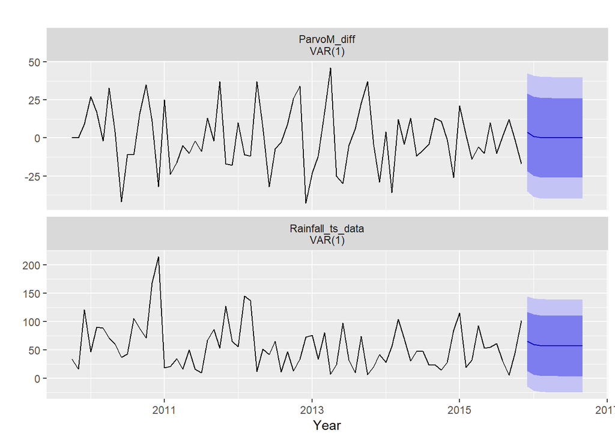

```r
# we plot forecasts from each predictive equation
forecast(Mod1) %>%
  autoplot() + xlab("Year")
```

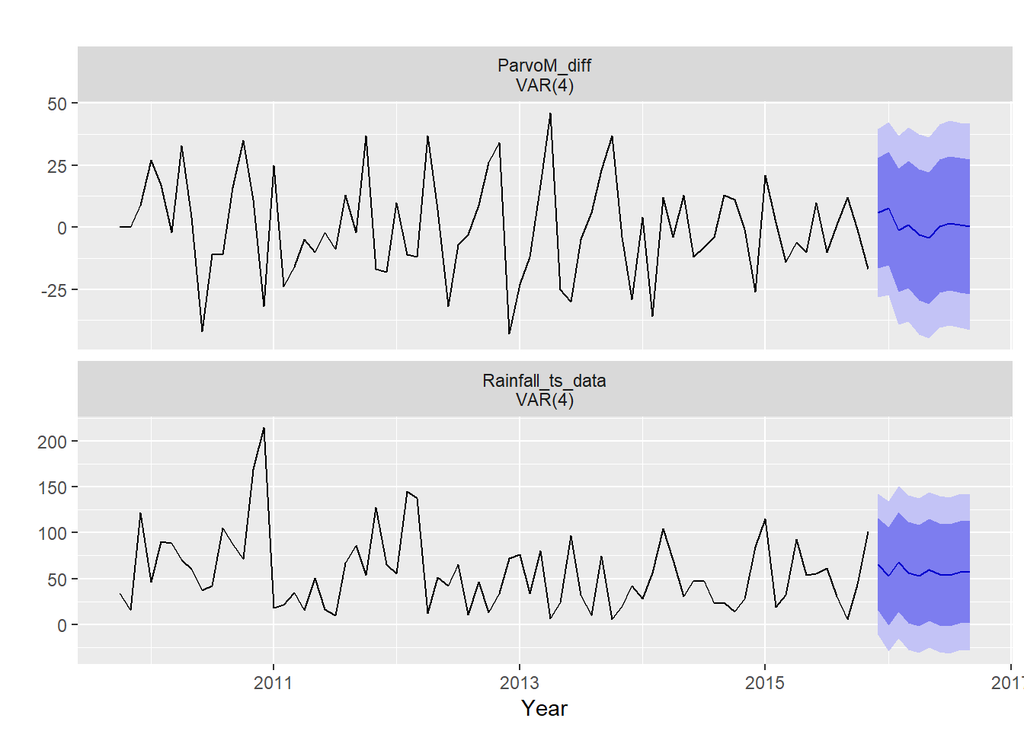

```r
forecast(Mod2) %>%
  autoplot() + xlab("Year")
```

In the model with p = 4, there are 18 coefficients (9 for each equation). There are significant predictors of parvo events (previous parvo events and rainfall at lags 2, 3 and 4). In the Portmanteau test, P = 0.58 (consistent with the null hypothesis of no correlation between residuals).

We would select the model with p = 4 as more useful for prediction of parvo events. In this case, we have no interest in prediction of rainfall, but this predictive equation would also be of interest if a plausible causal relationship was agreed ‘a priori’.

For further information about vector auto-regressive models and other extensions of time-series analysis and forecasting, we recommend:

Hyndman, R.J., & Athanasopoulos, G. (2018) Forecasting: principles and practice, 2nd edition, OTexts: Melbourne, Australia. OTexts.com/fpp2. Accessed on 24/10/2019.

An online copy of this book can be found [here](https://otexts.com/fpp2/).